# From a Single Cell to a Cell-Type Prediction: Analysis of Murine Hematopoietic scRNA-seq Data

## 13.6 Comparing Representations as Feature Spaces

The three representations are now compared as a set, using three criteria that each answer a different question: reconstruction MSE (already examined in detail in section 13.4) asks how much of the input each representation preserves; a post-hoc silhouette on the annotated cells' known types asks how well-separated the ten classes already are in each representation, without any classifier; and 15-nearest-neighbour trustworthiness of a UMAP built on each representation asks how faithfully that further 2D projection preserves the representation's own local neighbourhoods, in the same sense already used for the UMAP sensitivity analysis in section 10.2. None of these criteria is used to select a final model. That comparison, on held-out predictive performance, is the subject of section 14.

```python
exploratory_representations = {
    f"PCA-{LATENT_DIM}": pca_latent,
    f"AE-{LATENT_DIM}": ae_latent,
    f"DAE-{LATENT_DIM}": dae_latent,
}
reconstruction_mse = {
    f"PCA-{LATENT_DIM}": pca_val_mse,
    f"AE-{LATENT_DIM}": ae_fit["clean_validation_mse"],
    f"DAE-{LATENT_DIM}": dae_fit["clean_validation_mse"],
}

representation_rows = []
latent_umaps = {}
for name, representation in exploratory_representations.items():
    latent_umaps[name] = umap.UMAP(
        n_neighbors=15, min_dist=0.30, n_components=2,
        random_state=SEED, n_jobs=1,
    ).fit_transform(representation)
    representation_rows.append({
        "representation": name,
        "dimension": representation.shape[1],
        "clean_validation_reconstruction_MSE": reconstruction_mse[name],
        "posthoc_cell_type_silhouette": silhouette_score(
            representation[annotated_mask], known_types
        ),
        "15NN_trustworthiness_of_UMAP": trustworthiness(
            representation, latent_umaps[name], n_neighbors=15
        ),
    })

representation_exploration = pd.DataFrame(representation_rows).set_index("representation")
display(representation_exploration.style.format({
    "clean_validation_reconstruction_MSE": "{:.4f}",
    "posthoc_cell_type_silhouette": "{:.3f}",
    "15NN_trustworthiness_of_UMAP": "{:.3f}",
}))
```

| representation | dimension | clean_validation_reconstruction_MSE | posthoc_cell_type_silhouette | 15NN_trustworthiness_of_UMAP |
| --- | --- | --- | --- | --- |
| PCA-32 | 32 | 0.6450 | 0.035 | 0.932 |
| AE-32 | 32 | 0.6661 | 0.044 | 0.925 |
| DAE-32 | 32 | 0.6652 | 0.045 | 0.924 |

The three criteria do not agree on a single winner, which is why all three are reported. PCA-32 has the lowest reconstruction MSE (0.6450) and the highest UMAP trustworthiness (0.932), confirming at 32 dimensions what sections 13.4 and 13.5 suggested at the level of individual cells and latent axes. AE-32 and DAE-32 edge ahead on post-hoc silhouette (0.044 and 0.045 against PCA's 0.035), but all three sit close to zero on a scale where 1 would mean cleanly separated classes, so this is a small difference between three representations that are all weakly separated in absolute terms. That is consistent with everything else found about these ten classes: not evidence that the autoencoders discovered separability PCA misses, but a reminder that no 32-dimensional compression of this data, linear or not, produces cleanly standing-apart classes, because the underlying biology does not organise that way. Reconstruction fidelity and post-hoc class separation are different questions, and a representation can lead on one while trailing on the other.

## 13.7 UMAP View of the Three Representations

The same UMAP settings used throughout this notebook (`n_neighbors=15`, `min_dist=0.30`) are applied separately to each of the three 32-dimensional representations, purely as a visual complement to the numeric comparison above. No clustering or selection is performed on these coordinates, for the same reasons already given in section 10.

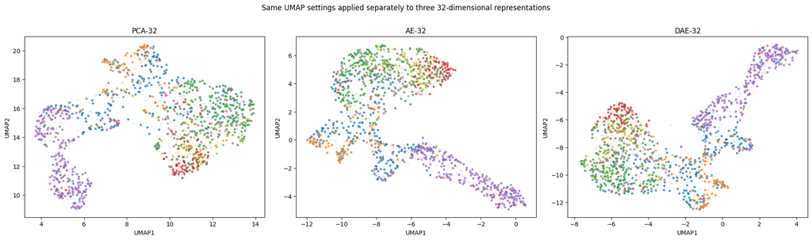

```python
fig, axes = plt.subplots(1, 3, figsize=(19, 5.5))
for ax, (name, embedding) in zip(axes, latent_umaps.items()):
    ax.scatter(
        embedding[~annotated_mask, 0], embedding[~annotated_mask, 1],
        color="#d9d9d9", s=13, alpha=0.45, linewidth=0,
    )
    for label in label_order:
        mask = annotated_mask & adata_analysis.obs["cell_type"].astype(object).eq(label).to_numpy()
        ax.scatter(
            embedding[mask, 0], embedding[mask, 1],
            s=15, alpha=0.75, color=palette[label], linewidth=0,
        )
    ax.set_title(name)
    ax.set_xlabel("UMAP1")
    ax.set_ylabel("UMAP2")
plt.suptitle(f"Same UMAP settings applied separately to three {LATENT_DIM}-dimensional representations", y=1.01)
plt.tight_layout()
plt.show()
```

All three panels show the structure already familiar from section 10: one population (purple, `MEP_broad`) separates from the rest to some degree in every representation, while the remaining classes overlap into a single connected body with no clean internal boundaries. Separation is clearest for PCA-32, where `MEP_broad` forms a mostly isolated island in the bottom-left, matching the reference UMAP on the 50-component space. AE-32 and DAE-32 stretch `MEP_broad` into a long tail extending away from the main body instead of a compact island, still recognisably distinct but with a less sharp boundary. This is the same pattern section 13.6 reported numerically (PCA's higher trustworthiness, the nonlinear models' marginally higher silhouette), shown geometrically: none of the three representations turns the remaining nine classes into separated islands, and the one class that stands out is the same one identified through PCA, UMAP, every clustering method in section 11, and the marker-correlation check in section 13.5.

Across this section, PCA reconstructs the scaled expression matrix slightly more faithfully than either neural representation at the same dimensionality, while AE and DAE remain close to one another. The latent-variance diagnostic shows that neither network collapses dimensions, and the marker correlations show that both retain several biologically interpretable programmes. Because the latent variances were sorted only for display, their decreasing profile is not evidence that the autoencoder learned an intrinsically PCA-like ordering.

These results do not demonstrate that the dataset contains no useful nonlinear structure. They show only that, within the architectures, data size, training procedure, and criteria examined here, the nonlinear bottlenecks did not provide a clear advantage over PCA. Reconstruction, silhouette, and trustworthiness also do not measure predictive usefulness directly. That question is addressed in section 14, where PCA, AE, and DAE representations are refitted within the same cross-validation folds and passed to common classifiers.

# 14. Supervised Cell-Type Classification

## 14.1 What Is Evaluated, and What Is Not

The 1,074 annotated cells are the only observations with known class labels. Model comparison therefore rests on **out-of-fold predictions** within this annotated subset. Let $D$ be divided into $K$ disjoint folds, $D=\bigcup_{k=1}^{K}D_k$ with $D_k\cap D_j=\emptyset$ for $k\neq j$. For each fold $k$, a model $f_{-k}$ is fitted on $D\setminus D_k$ and predicts the cells in $D_k$, so every prediction $\hat{y}_i=f_{-k(i)}(x_i)$ comes from a model that did not train on cell $i$. Pooling the three folds gives one out-of-fold prediction for every annotated cell without reserving a single small hold-out set.

One qualification is important: the same out-of-fold scores are used to compare seventeen model/representation combinations and select the best one. The reported macro-F1 of the selected model is therefore the maximum over several comparisons and may be mildly optimistic relative to performance on a completely independent cohort. Cross-validation makes the comparison substantially more reliable than a single split, but it is not external validation.

Class imbalance makes the protocol as important as the metrics. `other` has 6 cells and `MPP2_broad` 15, compared with 256 for `MEP_broad`. Three stratified outer folds are used as a pragmatic compromise: each validation fold contains two `other` cells while the corresponding training fold retains four. More folds are mathematically possible, but class-specific estimates would become increasingly unstable. Classical-model hyperparameters are selected by a two-fold stratified search confined to each outer training set, keeping the tuning loop separate from the evaluation fold.

Within each outer fold, four steps occur in this order:

1. the scaler is fitted only on the outer-training cells;
2. PCA or an autoencoder is fitted only on those scaled training cells;
3. model hyperparameters or a stopping epoch are selected without using the outer validation labels;
4. the resulting pipeline predicts the held-out cells, and only then are those predictions recorded.

Reversing this order—for example by fitting a scaler on all annotated cells or choosing hyperparameters from the outer validation scores—would leak evaluation information into training and inflate the reported metrics.

Three label-free design choices were made once using all 1,499 profiles rather than repeated inside every fold: the 1,000-gene HVG panel, `N_PCS = 50`, and the autoencoder architecture. These choices do not use cell-type labels, but they are globally informed and therefore transductive. By contrast, every fitted scaler, PCA, autoencoder and classifier used to generate an out-of-fold prediction is learned from the corresponding outer-training cells. No oversampling is used; class imbalance is handled through model-specific class weighting. Only after the model family and representation have been selected from out-of-fold results is the chosen pipeline refitted on all annotated cells and applied to the unannotated profiles in section 17.

```python
annotated_indices = np.flatnonzero(annotated_mask)
X_labeled = X_hvg_unscaled[annotated_mask]
y_labeled = adata_analysis.obs.loc[annotated_mask, "cluster"].astype(int).to_numpy()

class_codes = mapping_table["clusters"].astype(int).tolist()
code_to_label = dict(zip(
    mapping_table["clusters"].astype(int), mapping_table["cell_type"].astype(str)
))
short_label_by_code = {
    code: label.replace("_broad", "") for code, label in code_to_label.items()
}

outer_cv = StratifiedKFold(n_splits=3, shuffle=True, random_state=SEED)
outer_splits = list(outer_cv.split(X_labeled, y_labeled))

support_rows = []
for fold, (train_idx, test_idx) in enumerate(outer_splits, start=1):
    for split_name, indices in [("train", train_idx), ("validation", test_idx)]:
        counts = pd.Series(y_labeled[indices]).value_counts()
        for code_value in class_codes:
            support_rows.append({
                "fold": fold,
                "split": split_name,
                "class": short_label_by_code[code_value],
                "support": int(counts.get(code_value, 0)),
            })

cv_support = pd.DataFrame(support_rows)
display(cv_support.pivot_table(
    index=["class"], columns=["fold", "split"], values="support"
).astype(int))

print("Annotated matrix used for supervised evaluation:", X_labeled.shape)
```

| fold split class | 1 train | 1 validation | 2 train | 2 validation | 3 train | 3 validation |
| --- | --- | --- | --- | --- | --- | --- |
| CMP | 155 | 77 | 154 | 78 | 155 | 77 |
| GMP | 59 | 29 | 58 | 30 | 59 | 29 |
| LMPP | 117 | 59 | 117 | 59 | 118 | 58 |
| LTHSC | 50 | 25 | 50 | 25 | 50 | 25 |
| MEP | 171 | 85 | 171 | 85 | 170 | 86 |
| MPP1 | 29 | 14 | 29 | 14 | 28 | 15 |
| MPP2 | 10 | 5 | 10 | 5 | 10 | 5 |
| MPP3 | 73 | 37 | 74 | 36 | 73 | 37 |
| STHSC | 48 | 25 | 49 | 24 | 49 | 24 |
| other | 4 | 2 | 4 | 2 | 4 | 2 |

```
Annotated matrix used for supervised evaluation: (1074, 1000)
```

The table confirms the stratification worked as intended, class by class. `other` is split 4 training / 2 validation cells in every one of the three folds, and `MPP2_broad` is split 10/5 in every fold too, so the smallest classes keep an identical, stable shape across all three partitions, with no fold accidentally leaving either class entirely out of training or validation. The larger classes vary a little more in absolute counts between folds because 1,074 cells cannot always divide three ways into equal thirds (`MEP_broad` ranges between 170 and 171 training cells, `MPP3_broad` between 73 and 74), but the train/validation proportion stays close to 2:1 throughout for every class. This is the numeric confirmation of the design choice explained above: with `other` at only 6 cells total, three folds is close to the finest partition that still keeps every class meaningfully represented in every validation set.

## 14.2 Five Classifiers with Complementary Assumptions

**Multinomial logistic regression** is the linear baseline. It models class logits as $w_k^Tz+b_k$ and fits the weights by minimising the L2-penalised negative log-likelihood, $$-\frac{1}{n}\sum_{i=1}^{n}\log p(y_i\mid z_i;w,b) + \frac{1}{C}\sum_k\lVert w_k\rVert_2^2,$$ where $C$ is the inverse regularisation strength: small $C$ lets the penalty dominate and favours a simpler boundary, large $C$ fits the training folds more closely at the risk of overfitting small classes. Balanced class weights reweight each cell's contribution inversely to its class frequency, so the six `other` cells are not drowned out by the 256 `MEP_broad` ones. The inner search tests $C\in\{0.1,1.0,10.0\}$.

**Support Vector Machine** maximises the margin between classes instead of modelling class probabilities directly. A linear kernel tests whether the PCA coordinates are close to linearly separable; an RBF kernel allows curved boundaries by implicitly mapping into a higher-dimensional space. $C$ penalises points inside or across the margin, and $\gamma$ sets how local each training point's RBF influence is, with large $\gamma$ risking overfit boundaries around small classes. The inner search covers a linear kernel at $C\in\{0.1,1.0\}$ and an RBF kernel at $C\in\{1.0,10.0\}$ with $\gamma\in\{\text{scale},0.01\}$.

**Random Forest** averages many decision trees, each trained on a bootstrap resample of the training fold with a random subset of features considered at every split. It models nonlinear interactions between principal components with essentially no distributional assumptions, but probability estimates and feature importances become unstable when features are correlated and when some classes have very few examples to bootstrap from. The inner search covers `max_depth`$\in\{$None$,12\}$ and `min_samples_leaf`$\in\{1,2\}$, with 300 trees and balanced bootstrap sampling fixed throughout.

**XGBoost** builds shallow trees sequentially instead of averaging independent ones: each new tree corrects the residual errors of the current ensemble, using sample weights recomputed inside every training fold to keep the class-balancing logic of the other four models. The inner search covers `max_depth`$\in\{3,5\}$ and `learning_rate`$\in\{0.03,0.08\}$, with 250 boosting rounds, subsampling, and column subsampling fixed.

**Multilayer Perceptron (MLP)** stacks affine transformations and nonlinear ReLU activations, trained with multiclass cross-entropy, inverse-frequency class weights, dropout, weight decay, an internal validation split, and early stopping. Its training procedure and the formulas behind each regularisation technique are in section 14.3, because unlike the four above it is tuned by choosing how long to train rather than by a grid search.

All five classifiers see the same input in this section, PCA at `N_PCS` components fitted fresh inside every outer training fold, so any difference in their out-of-fold performance, reported in section 14.5, reflects a difference between the classifiers themselves and not between what each one was given to work with.

```python
def basic_metrics(y_true, y_pred):
    return {
        "accuracy": accuracy_score(y_true, y_pred),
        "macro_F1": f1_score(y_true, y_pred, average="macro", zero_division=0),
        "balanced_accuracy": balanced_accuracy_score(y_true, y_pred),
    }

def evaluate_classical_model(name, estimator, parameter_grid):
    oof_predictions = np.full(len(y_labeled), -1, dtype=int)
    fold_rows = []
    best_parameter_rows = []
    start_time = perf_counter()

    for fold, (train_idx, test_idx) in enumerate(outer_splits, start=1):
        pipeline = Pipeline([
            ("scale", StandardScaler()),
            ("pca", PCA(n_components=N_PCS, svd_solver="full")),
            ("model", clone(estimator)),
        ])
        inner_cv = StratifiedKFold(
            n_splits=2, shuffle=True, random_state=SEED + fold
        )
        search = GridSearchCV(
            pipeline,
            parameter_grid,
            scoring="f1_macro",
            cv=inner_cv,
            n_jobs=1,
            refit=True,
            error_score="raise",
        )
        fit_parameters = {}
        if name == "XGBoost":
            fit_parameters["model__sample_weight"] = compute_sample_weight(
                class_weight="balanced", y=y_labeled[train_idx]
            )
        search.fit(
            X_labeled[train_idx], y_labeled[train_idx], **fit_parameters
        )
        prediction = search.predict(X_labeled[test_idx]).astype(int)
        oof_predictions[test_idx] = prediction

        fold_rows.append({"fold": fold, **basic_metrics(y_labeled[test_idx], prediction)})
        best_parameter_rows.append({
            "fold": fold,
            "parameters": str({
                key.replace("model__", ""): value
                for key, value in search.best_params_.items()
            }),
            "inner_macro_F1": search.best_score_,
        })

    assert (oof_predictions >= 0).all()
    return {
        "name": name,
        "predictions": oof_predictions,
        "fold_metrics": pd.DataFrame(fold_rows),
        "best_parameters": pd.DataFrame(best_parameter_rows),
        "runtime_seconds": perf_counter() - start_time,
    }

classical_specs = {
    "Logistic Regression": (
        LogisticRegression(
            class_weight="balanced", max_iter=4000, solver="lbfgs", random_state=SEED
        ),
        {"model__C": [0.1, 1.0, 10.0]},
    ),
    "Support Vector Machine": (
        SVC(class_weight="balanced", probability=True, random_state=SEED),
        [
            {"model__kernel": ["linear"], "model__C": [0.1, 1.0]},
            {
                "model__kernel": ["rbf"], "model__C": [1.0, 10.0],
                "model__gamma": ["scale", 0.01],
            },
        ],
    ),
    "Random Forest": (
        RandomForestClassifier(
            n_estimators=300,
            class_weight="balanced_subsample",
            max_features="sqrt",
            min_samples_leaf=1,
            n_jobs=-1,
            random_state=SEED,
        ),
        {
            "model__max_depth": [None, 12],
            "model__min_samples_leaf": [1, 2],
        },
    ),
    "XGBoost": (
        XGBClassifier(
            objective="multi:softprob",
            num_class=len(class_codes),
            n_estimators=250,
            subsample=0.85,
            colsample_bytree=0.85,
            reg_lambda=1.0,
            eval_metric="mlogloss",
            tree_method="hist",
            n_jobs=-1,
            random_state=SEED,
        ),
        {
            "model__max_depth": [3, 5],
            "model__learning_rate": [0.03, 0.08],
        },
    ),
}

model_results = {}
for model_name, (estimator, grid) in classical_specs.items():
    print(f"Evaluating {model_name}...")
    model_results[model_name] = evaluate_classical_model(model_name, estimator, grid)
    display(model_results[model_name]["best_parameters"])
```

```
Evaluating Logistic Regression...
```

|  | fold | parameters | inner_macro_F1 |
| --- | --- | --- | --- |
| 0 | 1 | {'C': 0.1} | 0.370904 |
| 1 | 2 | {'C': 0.1} | 0.351264 |
| 2 | 3 | {'C': 0.1} | 0.358236 |

```
Evaluating Support Vector Machine...
```

|  | fold | parameters | inner_macro_F1 |
| --- | --- | --- | --- |
| 0 | 1 | {'C': 10.0, 'gamma': 'scale', 'kernel': 'rbf'} | 0.460295 |
| 1 | 2 | {'C': 1.0, 'gamma': 'scale', 'kernel': 'rbf'} | 0.372760 |
| 2 | 3 | {'C': 10.0, 'gamma': 'scale', 'kernel': 'rbf'} | 0.390937 |

```
Evaluating Random Forest...
```

|  | fold | parameters | inner_macro_F1 |
| --- | --- | --- | --- |
| 0 | 1 | {'max_depth': 12, 'min_samples_leaf': 2} | 0.377872 |
| 1 | 2 | {'max_depth': 12, 'min_samples_leaf': 2} | 0.377443 |
| 2 | 3 | {'max_depth': 12, 'min_samples_leaf': 2} | 0.358276 |

```
Evaluating XGBoost...
```

|  | fold | parameters | inner_macro_F1 |
| --- | --- | --- | --- |
| 0 | 1 | {'learning_rate': 0.03, 'max_depth': 3} | 0.402815 |
| 1 | 2 | {'learning_rate': 0.03, 'max_depth': 3} | 0.371024 |
| 2 | 3 | {'learning_rate': 0.03, 'max_depth': 5} | 0.395684 |

## 14.3 Small MLP with Early Stopping

The MLP has two hidden layers (64 and 32 units), ReLU activations, and 20% dropout, small by design: with only 1,074 labelled cells, more capacity would risk memorising the training fold instead of generalising. Four regularisation mechanisms work together, each addressing a different way a small network overfits a small dataset:

- **Class-weighted cross-entropy.** The loss for cell $i$ with true class $y_i$ is $-w_{y_i}\log p_\theta(y_i\mid x_i)$, where $w_c=\frac{n}{K\cdot n_c}$ gives class $c$ a weight inversely proportional to its training-fold frequency $n_c$ (the same "balanced" formula already used for Logistic Regression, Random Forest, and XGBoost in section 14.2). Without it, a network minimising an unweighted average loss could reach a low overall loss largely by ignoring the six `other` cells.
- **Dropout.** During training each hidden activation is independently zeroed with probability $p=0.20$ and survivors rescaled by $1/(1-p)$; nothing is dropped at prediction time. This stops the network relying on any single unit or narrow combination, spreading what it learns across its 64-32 capacity.
- **Weight decay.** AdamW applies decoupled weight decay, shrinking the model parameters directly at each update:

  $$ \theta \leftarrow \theta - \eta\nabla_\theta\mathcal{L} - \eta\lambda\theta $$

  Because this shrinkage is applied separately from the loss gradient, it discourages excessively large weights and helps reduce overfitting.
- **Early stopping.** Training stops when the validation loss does not improve for a predefined number of epochs. This acts as an implicit form of regularisation: limiting the number of optimisation steps reduces the opportunity for the network to fit noise or patterns specific to the training fold, without adding an explicit penalty to the loss function.

For each outer fold, an internal 80/20 stratified split of that fold's training cells chooses the epoch count alone: a fresh model trains epoch by epoch, its loss on the internal slice is tracked, training stops after 15 epochs without improvement, and the best epoch is recorded. The network is then reinitialised and trained for that many epochs on the *full* outer-training fold, internal validation cells included, so no labelled cell is discarded from the final fit. Scaling and PCA are also refitted on all outer-training cells, matching the fold-isolation protocol used by every other classifier here.

```python
class SmallMLP(nn.Module):
    def __init__(self, input_dim, n_classes):
        super().__init__()
        self.network = nn.Sequential(
            nn.Linear(input_dim, 64),
            nn.ReLU(),
            nn.Dropout(0.20),
            nn.Linear(64, 32),
            nn.ReLU(),
            nn.Dropout(0.20),
            nn.Linear(32, n_classes),
        )

    def forward(self, x):
        return self.network(x)

def class_weight_tensor(y):
    counts = np.bincount(y, minlength=len(class_codes)).astype(float)
    weights = len(y) / (len(class_codes) * np.maximum(counts, 1))
    return torch.tensor(weights, dtype=torch.float32, device=DEVICE)

def train_mlp_for_epochs(Z, y, epochs, seed):
    torch.manual_seed(seed)
    model = SmallMLP(Z.shape[1], len(class_codes)).to(DEVICE)
    optimizer = torch.optim.AdamW(model.parameters(), lr=1e-3, weight_decay=1e-4)
    criterion = nn.CrossEntropyLoss(weight=class_weight_tensor(y))
    generator = torch.Generator().manual_seed(seed)
    dataset = TensorDataset(
        torch.from_numpy(np.asarray(Z, dtype=np.float32)),
        torch.from_numpy(np.asarray(y, dtype=np.int64)),
    )
    loader = DataLoader(
        dataset, batch_size=64, shuffle=True, generator=generator, num_workers=0
    )
    history = []
    for epoch in range(1, epochs + 1):
        model.train()
        running = 0.0
        for features, target in loader:
            features, target = features.to(DEVICE), target.to(DEVICE)
            optimizer.zero_grad()
            loss = criterion(model(features), target)
            loss.backward()
            optimizer.step()
            running += loss.item() * len(features)
        history.append(running / len(dataset))
    return model, history

def predict_mlp(model, Z):
    model.eval()
    with torch.no_grad():
        logits = model(torch.from_numpy(np.asarray(Z, dtype=np.float32)).to(DEVICE))
        probabilities = torch.softmax(logits, dim=1).cpu().numpy()
    return probabilities.argmax(axis=1), probabilities

def choose_mlp_epoch(X_train_raw, y_train, seed, max_epochs=180, patience=15):
    subtrain_idx, val_idx = train_test_split(
        np.arange(len(y_train)),
        test_size=0.20,
        stratify=y_train,
        random_state=seed,
    )
    scaler = StandardScaler().fit(X_train_raw[subtrain_idx])
    Z_subtrain_scaled = scaler.transform(X_train_raw[subtrain_idx])
    Z_val_scaled = scaler.transform(X_train_raw[val_idx])
    pca = PCA(n_components=N_PCS, svd_solver="full").fit(Z_subtrain_scaled)
    Z_subtrain = pca.transform(Z_subtrain_scaled).astype(np.float32)
    Z_val = pca.transform(Z_val_scaled).astype(np.float32)

    torch.manual_seed(seed)
    model = SmallMLP(N_PCS, len(class_codes)).to(DEVICE)
    optimizer = torch.optim.AdamW(model.parameters(), lr=1e-3, weight_decay=1e-4)
    criterion = nn.CrossEntropyLoss(weight=class_weight_tensor(y_train[subtrain_idx]))
    generator = torch.Generator().manual_seed(seed)
    loader = DataLoader(
        TensorDataset(
            torch.from_numpy(Z_subtrain),
            torch.from_numpy(y_train[subtrain_idx].astype(np.int64)),
        ),
        batch_size=64, shuffle=True, generator=generator, num_workers=0,
    )
    val_features = torch.from_numpy(Z_val).to(DEVICE)
    val_targets = torch.from_numpy(y_train[val_idx].astype(np.int64)).to(DEVICE)

    best_epoch, best_loss = 1, np.inf
    epochs_without_improvement = 0
    history = []
    for epoch in range(1, max_epochs + 1):
        model.train()
        running = 0.0
        for features, target in loader:
            features, target = features.to(DEVICE), target.to(DEVICE)
            optimizer.zero_grad()
            loss = criterion(model(features), target)
            loss.backward()
            optimizer.step()
            running += loss.item() * len(features)
        model.eval()
        with torch.no_grad():
            val_loss = criterion(model(val_features), val_targets).item()
        history.append({
            "epoch": epoch,
            "training_loss": running / len(subtrain_idx),
            "validation_loss": val_loss,
        })
        if val_loss < best_loss - 1e-4:
            best_loss, best_epoch = val_loss, epoch
            epochs_without_improvement = 0
        else:
            epochs_without_improvement += 1
            if epochs_without_improvement >= patience:
                break
    return best_epoch, pd.DataFrame(history)

mlp_oof = np.full(len(y_labeled), -1, dtype=int)
mlp_fold_rows = []
mlp_epoch_rows = []
mlp_start = perf_counter()

for fold, (train_idx, test_idx) in enumerate(outer_splits, start=1):
    best_epoch, history = choose_mlp_epoch(
        X_labeled[train_idx], y_labeled[train_idx], seed=SEED + fold
    )
    scaler = StandardScaler().fit(X_labeled[train_idx])
    train_scaled = scaler.transform(X_labeled[train_idx])
    test_scaled = scaler.transform(X_labeled[test_idx])
    pca = PCA(n_components=N_PCS, svd_solver="full").fit(train_scaled)
    Z_train = pca.transform(train_scaled).astype(np.float32)
    Z_test = pca.transform(test_scaled).astype(np.float32)
    model, _ = train_mlp_for_epochs(
        Z_train, y_labeled[train_idx], best_epoch, seed=SEED + 100 + fold
    )
    prediction, _ = predict_mlp(model, Z_test)
    mlp_oof[test_idx] = prediction
    mlp_fold_rows.append({
        "fold": fold, **basic_metrics(y_labeled[test_idx], prediction)
    })
    mlp_epoch_rows.append({
        "fold": fold,
        "best_epoch": best_epoch,
        "best_internal_validation_loss": history["validation_loss"].min(),
    })

model_results["Multilayer Perceptron"] = {
    "name": "Multilayer Perceptron",
    "predictions": mlp_oof,
    "fold_metrics": pd.DataFrame(mlp_fold_rows),
    "best_parameters": pd.DataFrame(mlp_epoch_rows),
    "runtime_seconds": perf_counter() - mlp_start,
}
display(model_results["Multilayer Perceptron"]["best_parameters"])
```

|  | fold | best_epoch | best_internal_validation_loss |
| --- | --- | --- | --- |
| 0 | 1 | 18 | 2.149751 |
| 1 | 2 | 9 | 1.891756 |
| 2 | 3 | 9 | 1.984693 |

The chosen epoch varies more across folds than any of the four classical models' hyperparameters did: 18 epochs in fold 1, only 9 in both fold 2 and fold 3, with internal validation loss at that best epoch ranging from 1.892 (fold 2) to 2.150 (fold 1). An MLP trained from randomly initialised weights on a few hundred cells is inherently more sensitive to which cells end up in the internal training split than a regularised linear model or an ensemble of trees is, so this degree of fold-to-fold variation in the stopping point is expected and not a sign of a faulty procedure. It is why the epoch count is re-selected independently inside every outer fold instead of fixed once for all three.

## 14.4 Controlled Comparison of Representations

Section 14.2 already evaluates five classifiers, but all five see the same input: PCA at `N_PCS` components. That leaves two separate questions unanswered: does the *representation* matter, holding the classifier fixed, and does compressing to a handful of dimensions cost anything relative to using all 1,000 HVGs directly? Both are addressed together: four representations (PCA at `LATENT_DIM` components, the AE latent space, the DAE latent space, and the raw scaled HVG matrix) are each fed into three classifiers: the fixed-$C$ logistic regression used before, the small MLP from section 14.3 with its own epoch selection per representation, and an RBF-kernel SVM.

SVM is included here and Random Forest and XGBoost are not, and that split is a design choice, not a matter of time. Logistic regression, SVM, and the MLP are all, in different ways, sensitive to the *geometry* of the space they are given. Distances, margins, and decision boundaries are all defined relative to that geometry, so asking whether the representation matters is a meaningful question for them. Random Forest and XGBoost split on one feature at a time: which axes are available changes what they can find, but the notion of geometry separating PCA from an autoencoder manifold from the raw HVG space is largely irrelevant to how a tree decides a split. Both already handle 1,000 raw features, which is why section 14.2 lets them see PCA only.

This gives twelve representation-classifier combinations, each evaluated through the same three outer folds as every other model in this section, with the scaler, PCA, and both autoencoders refitted independently inside every training fold. No fitted transformation ever sees its own validation fold.

Results are reported per combination here; the comparison across all seventeen models is deferred to section 15.

```python
def select_mlp_epoch(Z_train, y_train, seed, max_epochs=150, patience=15):
    subtrain_idx, val_idx = train_test_split(
        np.arange(len(y_train)), test_size=0.20, stratify=y_train, random_state=seed,
    )
    torch.manual_seed(seed)
    model = SmallMLP(Z_train.shape[1], len(class_codes)).to(DEVICE)
    optimizer = torch.optim.AdamW(model.parameters(), lr=1e-3, weight_decay=1e-4)
    criterion = nn.CrossEntropyLoss(weight=class_weight_tensor(y_train[subtrain_idx]))
    generator = torch.Generator().manual_seed(seed)
    loader = DataLoader(
        TensorDataset(
            torch.from_numpy(Z_train[subtrain_idx].astype(np.float32)),
            torch.from_numpy(y_train[subtrain_idx].astype(np.int64)),
        ),
        batch_size=64, shuffle=True, generator=generator, num_workers=0,
    )
    val_features = torch.from_numpy(Z_train[val_idx].astype(np.float32)).to(DEVICE)
    val_targets = torch.from_numpy(y_train[val_idx].astype(np.int64)).to(DEVICE)

    best_epoch, best_loss, epochs_without_improvement = 1, np.inf, 0
    for epoch in range(1, max_epochs + 1):
        model.train()
        for features, target in loader:
            features, target = features.to(DEVICE), target.to(DEVICE)
            optimizer.zero_grad()
            loss = criterion(model(features), target)
            loss.backward()
            optimizer.step()
        model.eval()
        with torch.no_grad():
            val_loss = criterion(model(val_features), val_targets).item()
        if val_loss < best_loss - 1e-4:
            best_loss, best_epoch, epochs_without_improvement = val_loss, epoch, 0
        else:
            epochs_without_improvement += 1
            if epochs_without_improvement >= patience:
                break
    return best_epoch

representation_labels = [f"PCA-{LATENT_DIM}", f"AE-{LATENT_DIM}", f"DAE-{LATENT_DIM}", "Raw HVGs"]
representation_names = [
    f"{classifier} on {representation}"
    for representation in representation_labels
    for classifier in ["Logistic", "MLP", "SVM"]
]
representation_oof = {
    name: np.full(len(y_labeled), -1, dtype=int) for name in representation_names
}
representation_fold_rows = {name: [] for name in representation_names}
representation_runtime = {name: 0.0 for name in representation_names}
representation_training_rows = []

for fold, (train_idx, test_idx) in enumerate(outer_splits, start=1):
    scaler = StandardScaler().fit(X_labeled[train_idx])
    train_scaled = scaler.transform(X_labeled[train_idx]).astype(np.float32)
    test_scaled = scaler.transform(X_labeled[test_idx]).astype(np.float32)
    y_train_fold, y_test_fold = y_labeled[train_idx], y_labeled[test_idx]

    fold_pca = PCA(n_components=LATENT_DIM, svd_solver="full").fit(train_scaled)
    representations = {
        f"PCA-{LATENT_DIM}": (fold_pca.transform(train_scaled), fold_pca.transform(test_scaled)),
        "Raw HVGs": (train_scaled, test_scaled),
    }
    for short_name, noise_std in [("AE", 0.0), ("DAE", 0.15)]:
        start = perf_counter()
        fitted = fit_autoencoder(
            train_scaled,
            noise_std=noise_std,
            seed=SEED + fold,
            latent_dim=LATENT_DIM,
            hidden_dim=HIDDEN_DIM,
            max_epochs=90,
            patience=10,
            validation_fraction=0.15,
        )
        representations[f"{short_name}-{LATENT_DIM}"] = (
            encode_matrix(fitted["model"], train_scaled),
            encode_matrix(fitted["model"], test_scaled),
        )
        representation_training_rows.append({
            "fold": fold,
            "representation": short_name,
            "epochs": fitted["epochs"],
            "clean_validation_MSE": fitted["clean_validation_mse"],
        })

    for rep_name, (Z_train, Z_test) in representations.items():
        start = perf_counter()
        logistic = LogisticRegression(
            C=1.0, class_weight="balanced", max_iter=4000, random_state=SEED
        ).fit(Z_train, y_train_fold)
        prediction = logistic.predict(Z_test).astype(int)
        name = f"Logistic on {rep_name}"
        representation_runtime[name] += perf_counter() - start
        representation_oof[name][test_idx] = prediction
        representation_fold_rows[name].append({
            "fold": fold, **basic_metrics(y_test_fold, prediction)
        })

        start = perf_counter()
        best_epoch = select_mlp_epoch(Z_train, y_train_fold, seed=SEED + fold)
        mlp_model, _ = train_mlp_for_epochs(
            Z_train, y_train_fold, best_epoch, seed=SEED + 100 + fold
        )
        prediction, _ = predict_mlp(mlp_model, Z_test)
        name = f"MLP on {rep_name}"
        representation_runtime[name] += perf_counter() - start
        representation_oof[name][test_idx] = prediction
        representation_fold_rows[name].append({
            "fold": fold, **basic_metrics(y_test_fold, prediction)
        })

        start = perf_counter()
        svm = SVC(
            kernel="rbf", C=1.0, gamma="scale", class_weight="balanced", random_state=SEED
        ).fit(Z_train, y_train_fold)
        prediction = svm.predict(Z_test).astype(int)
        name = f"SVM on {rep_name}"
        representation_runtime[name] += perf_counter() - start
        representation_oof[name][test_idx] = prediction
        representation_fold_rows[name].append({
            "fold": fold, **basic_metrics(y_test_fold, prediction)
        })

for name in representation_names:
    dimension_note = (
        f"{LATENT_DIM} dimensions" if "Raw" not in name
        else f"{X_labeled.shape[1]} dimensions (no reduction)"
    )
    model_results[name] = {
        "name": name,
        "predictions": representation_oof[name],
        "fold_metrics": pd.DataFrame(representation_fold_rows[name]),
        "best_parameters": pd.DataFrame([{"parameters": dimension_note}]),
        "runtime_seconds": representation_runtime[name],
    }

representation_training = pd.DataFrame(representation_training_rows)
display(representation_training.style.format({"clean_validation_MSE": "{:.4f}"}))
```

|  | fold | representation | epochs | clean_validation_MSE |
| --- | --- | --- | --- | --- |
| 0 | 1 | AE | 47 | 0.8029 |
| 1 | 1 | DAE | 51 | 0.8008 |
| 2 | 2 | AE | 48 | 0.7662 |
| 3 | 2 | DAE | 48 | 0.7653 |
| 4 | 3 | AE | 47 | 0.7981 |
| 5 | 3 | DAE | 50 | 0.7975 |

The AE and DAE refitted inside each outer fold converge in a similar number of epochs to their exploratory counterparts in section 13.3 (47-51 here against 44-47 there), with the DAE taking as long as or longer than the AE in every fold (51 vs 47, 48 vs 48, 50 vs 47). The noise-corrupted reconstruction objective is modestly harder to optimise, as already observed in section 13.3. The clean validation MSE reached here (0.7653-0.8029) is noticeably higher than the 0.665 found in section 13 on the full dataset, which is the direct, expected cost of the nested protocol: each fold's autoencoder sees only its own two-thirds training split, roughly 716 cells following the 2:1 train/validation ratio confirmed in section 14.1's fold table, instead of all 1,499, and a smaller training set gives both networks a harder reconstruction problem to solve. Fold 2 reaches a noticeably lower MSE for both networks (0.7662 and 0.7653) than folds 1 and 3 (around 0.80), which is consistent with ordinary sampling variation between three different two-thirds subsets of a comparatively small dataset, not with any systematic difference between the folds. None of this is a discrepancy to explain away. It is what fitting every representation fresh inside each fold, with no access to validation or unannotated cells, is supposed to produce, and it is why the reconstruction numbers from this section and from section 13 are never compared directly.

## 14.5 Metrics and Why One Number Is Insufficient

- **Accuracy**, $\frac{1}{n}\sum_i\mathbb{1}[\hat{y}_i=y_i]$, is the fraction of all correct predictions and is dominated by large classes: a model that always predicts `MEP_broad` would already be right on roughly 24% of all annotated cells (256 of 1,074) without learning anything about the other nine classes.
- **Macro-F1** instead computes precision, recall, and $F1_c=\frac{2\cdot\text{precision}_c\cdot\text{recall}_c}{\text{precision}_c+\text{recall}_c}$ separately within each class $c$ and averages the ten resulting $F1_c$ values with equal weight, $\frac{1}{10}\sum_c F1_c$, so a model that ignores `other` entirely is penalised just as much as one that ignores `MEP_broad` entirely, regardless of how many cells each class actually has.
- **Balanced accuracy**, $\frac{1}{10}\sum_c\text{recall}_c$, is closer still to a single interpretable number: the average, across the ten classes, of what fraction of each class's own cells were correctly recovered. All three are reported, with their variation across the three outer folds, per-class precision/recall/F1, and confusion matrices, because each answers a different question and none alone judges seventeen models fairly.

With two `other` observations per outer validation fold, rare-class estimates have intrinsically high variance: one cell moving from correct to incorrect changes that class's fold recall by 50 percentage points. A zero or perfect recall for `other` in any fold can flip on a single cell, and is read here as a symptom of sample size rather than a property of the class.

```python
summary_rows = []
per_class_rows = []

for name, result in model_results.items():
    prediction = result["predictions"]
    folds = result["fold_metrics"]
    overall = basic_metrics(y_labeled, prediction)
    summary_rows.append({
        "model": name,
        "OOF_accuracy": overall["accuracy"],
        "OOF_macro_F1": overall["macro_F1"],
        "OOF_balanced_accuracy": overall["balanced_accuracy"],
        "fold_accuracy_mean": folds["accuracy"].mean(),
        "fold_accuracy_sd": folds["accuracy"].std(ddof=1),
        "fold_macro_F1_mean": folds["macro_F1"].mean(),
        "fold_macro_F1_sd": folds["macro_F1"].std(ddof=1),
        "fold_balanced_accuracy_mean": folds["balanced_accuracy"].mean(),
        "fold_balanced_accuracy_sd": folds["balanced_accuracy"].std(ddof=1),
        "runtime_seconds": result["runtime_seconds"],
    })

    precision, recall, f1, support = precision_recall_fscore_support(
        y_labeled, prediction, labels=class_codes, zero_division=0
    )
    for code_value, p, r, f, n in zip(class_codes, precision, recall, f1, support):
        per_class_rows.append({
            "model": name,
            "class_code": code_value,
            "cell_type": short_label_by_code[code_value],
            "precision": p,
            "recall": r,
            "F1": f,
            "support": int(n),
        })

model_metric_summary = pd.DataFrame(summary_rows).set_index("model")
per_class_metrics = pd.DataFrame(per_class_rows)

display(model_metric_summary.style.format("{:.3f}"))
display(per_class_metrics.pivot(
    index="cell_type", columns="model", values="recall"
).style.format("{:.2f}").background_gradient(cmap="Blues", axis=None, vmin=0, vmax=1))
display(per_class_metrics.pivot(
    index="cell_type", columns="model", values="F1"
).style.format("{:.2f}").background_gradient(cmap="Greens", axis=None, vmin=0, vmax=1))
```

| model | OOF_accuracy | OOF_macro_F1 | OOF_balanced_accuracy | fold_accuracy_mean | fold_accuracy_sd | fold_macro_F1_mean | fold_macro_F1_sd | fold_balanced_accuracy_mean | fold_balanced_accuracy_sd | runtime_seconds |
| --- | --- | --- | --- | --- | --- | --- | --- | --- | --- | --- |
| Logistic Regression | 0.578 | 0.418 | 0.422 | 0.578 | 0.016 | 0.416 | 0.011 | 0.422 | 0.011 | 25.687 |
| Support Vector Machine | 0.609 | 0.420 | 0.422 | 0.609 | 0.006 | 0.418 | 0.004 | 0.422 | 0.010 | 5.999 |
| Random Forest | 0.629 | 0.418 | 0.416 | 0.629 | 0.011 | 0.413 | 0.010 | 0.417 | 0.009 | 13.906 |
| XGBoost | 0.608 | 0.410 | 0.414 | 0.608 | 0.024 | 0.407 | 0.018 | 0.414 | 0.021 | 28.880 |
| Multilayer Perceptron | 0.547 | 0.374 | 0.402 | 0.547 | 0.002 | 0.365 | 0.021 | 0.402 | 0.023 | 2.718 |
| Logistic on PCA-32 | 0.570 | 0.410 | 0.416 | 0.570 | 0.032 | 0.412 | 0.036 | 0.415 | 0.035 | 0.251 |
| MLP on PCA-32 | 0.547 | 0.390 | 0.408 | 0.547 | 0.042 | 0.385 | 0.033 | 0.408 | 0.021 | 0.653 |
| SVM on PCA-32 | 0.599 | 0.430 | 0.440 | 0.599 | 0.016 | 0.427 | 0.019 | 0.440 | 0.018 | 0.093 |
| Logistic on AE-32 | 0.545 | 0.393 | 0.415 | 0.545 | 0.017 | 0.392 | 0.020 | 0.415 | 0.019 | 0.189 |
| MLP on AE-32 | 0.560 | 0.376 | 0.402 | 0.560 | 0.016 | 0.373 | 0.038 | 0.402 | 0.029 | 0.678 |
| SVM on AE-32 | 0.571 | 0.405 | 0.424 | 0.571 | 0.003 | 0.401 | 0.015 | 0.425 | 0.026 | 0.087 |
| Logistic on DAE-32 | 0.540 | 0.387 | 0.404 | 0.540 | 0.008 | 0.386 | 0.002 | 0.404 | 0.006 | 0.172 |
| MLP on DAE-32 | 0.509 | 0.320 | 0.367 | 0.509 | 0.011 | 0.309 | 0.009 | 0.367 | 0.018 | 0.520 |
| SVM on DAE-32 | 0.580 | 0.416 | 0.433 | 0.580 | 0.011 | 0.412 | 0.019 | 0.433 | 0.025 | 0.083 |
| Logistic on Raw HVGs | 0.575 | 0.391 | 0.390 | 0.575 | 0.028 | 0.390 | 0.045 | 0.390 | 0.035 | 5.380 |
| MLP on Raw HVGs | 0.547 | 0.390 | 0.406 | 0.547 | 0.071 | 0.388 | 0.076 | 0.407 | 0.051 | 1.206 |
| SVM on Raw HVGs | 0.602 | 0.390 | 0.406 | 0.602 | 0.004 | 0.388 | 0.007 | 0.406 | 0.004 | 1.027 |

| model cell_type | Logistic Regression | Logistic on AE-32 | Logistic on DAE-32 | Logistic on PCA-32 | Logistic on Raw HVGs | MLP on AE-32 | MLP on DAE-32 | MLP on PCA-32 | MLP on Raw HVGs | Multilayer Perceptron | Random Forest | SVM on AE-32 | SVM on DAE-32 | SVM on PCA-32 | SVM on Raw HVGs | Support Vector Machine | XGBoost |
| --- | --- | --- | --- | --- | --- | --- | --- | --- | --- | --- | --- | --- | --- | --- | --- | --- | --- |
| CMP | 0.57 | 0.49 | 0.48 | 0.56 | 0.60 | 0.39 | 0.23 | 0.42 | 0.38 | 0.38 | 0.69 | 0.50 | 0.49 | 0.56 | 0.61 | 0.66 | 0.61 |
| GMP | 0.56 | 0.58 | 0.55 | 0.55 | 0.53 | 0.66 | 0.70 | 0.62 | 0.66 | 0.68 | 0.55 | 0.62 | 0.62 | 0.62 | 0.60 | 0.57 | 0.59 |
| LMPP | 0.59 | 0.50 | 0.51 | 0.56 | 0.63 | 0.76 | 0.69 | 0.48 | 0.41 | 0.68 | 0.77 | 0.63 | 0.64 | 0.67 | 0.73 | 0.62 | 0.69 |
| LTHSC | 0.43 | 0.29 | 0.28 | 0.43 | 0.40 | 0.40 | 0.40 | 0.47 | 0.56 | 0.41 | 0.48 | 0.28 | 0.31 | 0.35 | 0.63 | 0.36 | 0.45 |
| MEP | 0.87 | 0.90 | 0.89 | 0.85 | 0.91 | 0.93 | 0.93 | 0.91 | 0.94 | 0.93 | 0.93 | 0.91 | 0.91 | 0.88 | 0.86 | 0.90 | 0.93 |
| MPP1 | 0.37 | 0.30 | 0.35 | 0.40 | 0.21 | 0.44 | 0.53 | 0.47 | 0.28 | 0.49 | 0.19 | 0.51 | 0.53 | 0.51 | 0.02 | 0.40 | 0.28 |
| MPP2 | 0.13 | 0.40 | 0.27 | 0.07 | 0.07 | 0.07 | 0.00 | 0.07 | 0.07 | 0.13 | 0.00 | 0.20 | 0.13 | 0.07 | 0.00 | 0.00 | 0.00 |
| MPP3 | 0.33 | 0.28 | 0.29 | 0.37 | 0.23 | 0.11 | 0.15 | 0.40 | 0.44 | 0.15 | 0.25 | 0.23 | 0.27 | 0.30 | 0.32 | 0.40 | 0.31 |
| STHSC | 0.37 | 0.40 | 0.42 | 0.38 | 0.33 | 0.27 | 0.03 | 0.25 | 0.33 | 0.16 | 0.32 | 0.36 | 0.41 | 0.44 | 0.29 | 0.32 | 0.27 |
| other | 0.00 | 0.00 | 0.00 | 0.00 | 0.00 | 0.00 | 0.00 | 0.00 | 0.00 | 0.00 | 0.00 | 0.00 | 0.00 | 0.00 | 0.00 | 0.00 | 0.00 |

| model cell_type | Logistic Regression | Logistic on AE-32 | Logistic on DAE-32 | Logistic on PCA-32 | Logistic on Raw HVGs | MLP on AE-32 | MLP on DAE-32 | MLP on PCA-32 | MLP on Raw HVGs | Multilayer Perceptron | Random Forest | SVM on AE-32 | SVM on DAE-32 | SVM on PCA-32 | SVM on Raw HVGs | Support Vector Machine | XGBoost |
| --- | --- | --- | --- | --- | --- | --- | --- | --- | --- | --- | --- | --- | --- | --- | --- | --- | --- |
| CMP | 0.63 | 0.57 | 0.57 | 0.62 | 0.61 | 0.50 | 0.33 | 0.51 | 0.50 | 0.49 | 0.65 | 0.59 | 0.58 | 0.63 | 0.65 | 0.68 | 0.62 |
| GMP | 0.51 | 0.52 | 0.49 | 0.50 | 0.52 | 0.53 | 0.48 | 0.51 | 0.55 | 0.55 | 0.60 | 0.59 | 0.58 | 0.58 | 0.61 | 0.56 | 0.56 |
| LMPP | 0.59 | 0.53 | 0.55 | 0.59 | 0.56 | 0.65 | 0.58 | 0.53 | 0.48 | 0.60 | 0.65 | 0.61 | 0.63 | 0.63 | 0.62 | 0.62 | 0.64 |
| LTHSC | 0.46 | 0.33 | 0.32 | 0.46 | 0.43 | 0.43 | 0.41 | 0.47 | 0.52 | 0.40 | 0.52 | 0.35 | 0.39 | 0.44 | 0.46 | 0.45 | 0.50 |
| MEP | 0.87 | 0.87 | 0.86 | 0.86 | 0.89 | 0.88 | 0.87 | 0.88 | 0.88 | 0.87 | 0.88 | 0.87 | 0.87 | 0.87 | 0.87 | 0.88 | 0.88 |
| MPP1 | 0.27 | 0.23 | 0.26 | 0.29 | 0.23 | 0.26 | 0.29 | 0.28 | 0.25 | 0.29 | 0.21 | 0.32 | 0.34 | 0.32 | 0.04 | 0.29 | 0.27 |
| MPP2 | 0.15 | 0.22 | 0.14 | 0.06 | 0.11 | 0.06 | 0.00 | 0.06 | 0.07 | 0.14 | 0.00 | 0.11 | 0.09 | 0.06 | 0.00 | 0.00 | 0.00 |
| MPP3 | 0.31 | 0.29 | 0.29 | 0.34 | 0.26 | 0.15 | 0.19 | 0.35 | 0.34 | 0.20 | 0.33 | 0.26 | 0.29 | 0.33 | 0.34 | 0.38 | 0.34 |
| STHSC | 0.39 | 0.36 | 0.39 | 0.38 | 0.31 | 0.31 | 0.05 | 0.31 | 0.32 | 0.20 | 0.34 | 0.35 | 0.40 | 0.44 | 0.31 | 0.33 | 0.28 |
| other | 0.00 | 0.00 | 0.00 | 0.00 | 0.00 | 0.00 | 0.00 | 0.00 | 0.00 | 0.00 | 0.00 | 0.00 | 0.00 | 0.00 | 0.00 | 0.00 | 0.00 |

All seventeen models are reported here as results; which one to prefer is the subject of section 15. Several patterns stand out.

**The range is narrow.** Out-of-fold macro-F1 spans 0.320 (MLP on DAE-32) to 0.430 (SVM on PCA-32) across seventeen very different combinations, a spread of about 0.11 on a scale where 1 would be perfect. No single choice of representation or classifier transforms performance; every combination lands in a similar, moderate range.

**Among the five classifiers on `N_PCS`-component PCA (sections 14.2-14.3):** Support Vector Machine (0.420) and Logistic Regression (0.418) lead, Random Forest (0.418) is level with Logistic, XGBoost (0.410) trails slightly, and the Multilayer Perceptron (0.374) is clearly last. Before the representation comparison begins, the MLP is already the weakest classifier tested.

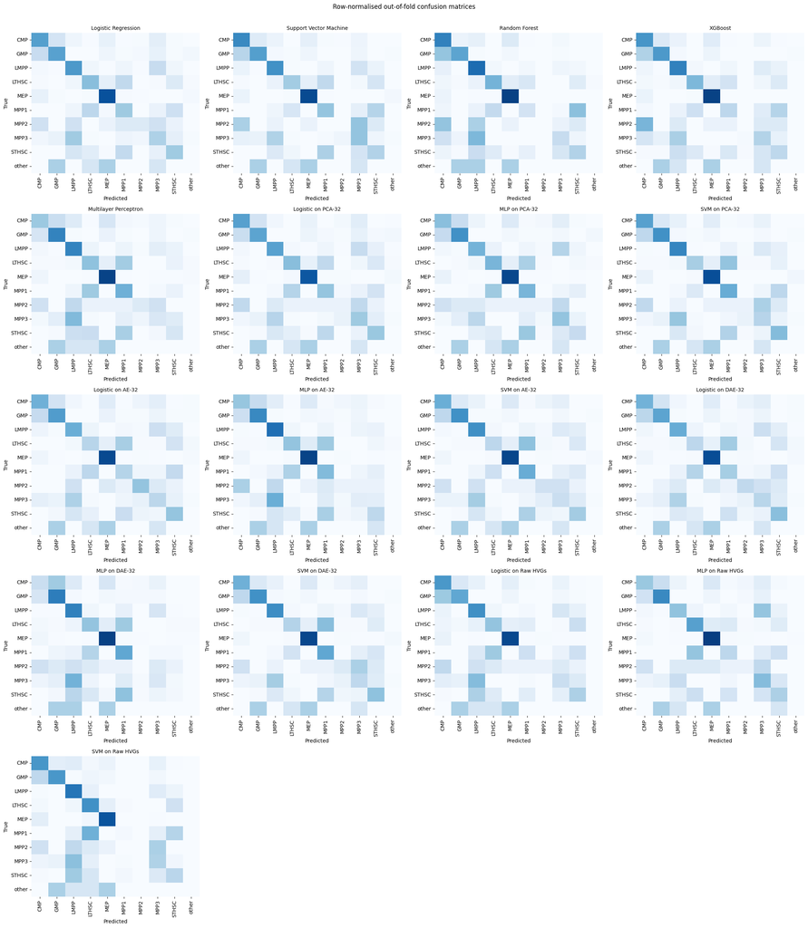

```python
n_models = len(model_results)
n_cols = 4
n_rows = -(-n_models // n_cols)
fig, axes = plt.subplots(n_rows, n_cols, figsize=(5.5 * n_cols, 5 * n_rows))
for ax, (name, result) in zip(axes.flat, model_results.items()):
    matrix = confusion_matrix(
        y_labeled, result["predictions"], labels=class_codes, normalize="true"
    )
    sns.heatmap(
        matrix, cmap="Blues", vmin=0, vmax=1, cbar=False,
        xticklabels=[short_label_by_code[x] for x in class_codes],
        yticklabels=[short_label_by_code[x] for x in class_codes],
        ax=ax,
    )
    ax.set_title(name, fontsize=10)
    ax.set_xlabel("Predicted")
    ax.set_ylabel("True")
for ax in axes.flat[n_models:]:
    ax.axis("off")
plt.suptitle("Row-normalised out-of-fold confusion matrices", y=1.005)
plt.tight_layout()
plt.show()
```

Both findings from the metrics tables are visible in every one of the seventeen panels. `MEP_broad`'s diagonal cell is the darkest anywhere in each panel, with almost no mass leaking to other columns, the clearest and most consistent block in the grid. The `other` row is pale and scattered across several columns instead of concentrated anywhere, including on its own diagonal, which is the visual form of its 0.00 recall everywhere.

Away from those two extremes, confusion is not random: where mass leaves the diagonal it goes to biologically adjacent classes. `CMP_broad` and `GMP_broad` exchange visible probability in nearly every panel, and `MPP1_broad`, `MPP3_broad`, and `STHSC_broad`, all with weak diagonals of their own, mix with each other and with `LMPP_broad` and `LTHSC_broad` instead of with `MEP_broad` or `GMP_broad`. The pattern holds across all seventeen models regardless of representation or classifier, which suggests real similarity between neighbouring progenitor states rather than an artefact of one modelling choice.

One panel departs sharply enough to name. SVM on Raw HVGs has an `MPP1_broad` recall of just **0.02**, effectively never recovering the class, even though SVM reaches 0.40-0.53 recall for it on every other representation, and the same panel simultaneously reaches the *highest* `LTHSC_broad` recall of the seventeen, **0.63**. Those `MPP1_broad` cells are not scattered evenly across the matrix: the mass in that row concentrates into `LTHSC_broad` and the other stem/multipotent neighbours. The model is not failing randomly, it is consistently relabelling one adjacent class as another. A single averaged score can hide a large, specific redistribution of errors that only the full confusion matrix reveals. Which confusions are most informative, and what they say about the ten-class annotation, is developed in section 15.

# 15. Final Model Comparison and Error Interpretation

```python
final_ranking = model_metric_summary.sort_values(
    ["OOF_macro_F1", "OOF_balanced_accuracy", "fold_macro_F1_sd", "OOF_accuracy"],
    ascending=[False, False, True, False],
)
FINAL_MODEL_NAME = final_ranking.index[0]
print("Selected final model:", FINAL_MODEL_NAME)
```

```
Selected final model: SVM on PCA-32
```

```python
selected_oof = model_results[FINAL_MODEL_NAME]["predictions"]
selected_confusion = confusion_matrix(
    y_labeled, selected_oof, labels=class_codes
)
off_diagonal = selected_confusion.copy()
np.fill_diagonal(off_diagonal, 0)

confusion_rows = []
for true_position, predicted_position in zip(*np.where(off_diagonal > 0)):
    confusion_rows.append({
        "true": short_label_by_code[class_codes[true_position]],
        "predicted": short_label_by_code[class_codes[predicted_position]],
        "count": int(off_diagonal[true_position, predicted_position]),
    })
top_confusions = pd.DataFrame(confusion_rows).sort_values(
    "count", ascending=False
).reset_index(drop=True)
display(top_confusions.head(12))

def bidirectional_error(label_a, label_b):
    code_a = next(code for code, label in short_label_by_code.items() if label == label_a)
    code_b = next(code for code, label in short_label_by_code.items() if label == label_b)
    ia, ib = class_codes.index(code_a), class_codes.index(code_b)
    return int(selected_confusion[ia, ib] + selected_confusion[ib, ia])

expected_error_pairs = pd.DataFrame([
    {"pair": "LTHSC - STHSC", "bidirectional errors": bidirectional_error("LTHSC", "STHSC")},
    {"pair": "MPP3 - CMP", "bidirectional errors": bidirectional_error("MPP3", "CMP")},
    {"pair": "MPP3 - GMP", "bidirectional errors": bidirectional_error("MPP3", "GMP")},
    {"pair": "CMP - GMP", "bidirectional errors": bidirectional_error("CMP", "GMP")},
    {"pair": "MPP2 - MEP", "bidirectional errors": bidirectional_error("MPP2", "MEP")},
])
display(expected_error_pairs.sort_values("bidirectional errors", ascending=False))

selected_per_class = per_class_metrics.loc[
    per_class_metrics["model"].eq(FINAL_MODEL_NAME)
].sort_values("recall")
display(selected_per_class)
```

|  | true | predicted | count |
| --- | --- | --- | --- |
| 0 | MPP3 | LMPP | 43 |
| 1 | CMP | GMP | 34 |
| 2 | LTHSC | MPP1 | 30 |
| 3 | CMP | MEP | 25 |
| 4 | LMPP | MPP3 | 25 |
| 5 | GMP | CMP | 24 |
| 6 | STHSC | MPP1 | 23 |
| 7 | CMP | LMPP | 19 |
| 8 | MEP | CMP | 18 |
| 9 | CMP | MPP3 | 17 |
| 10 | LMPP | STHSC | 15 |
| 11 | LMPP | MPP1 | 12 |

|  | pair | bidirectional errors |
| --- | --- | --- |
| 3 | CMP - GMP | 58 |
| 1 | MPP3 - CMP | 21 |
| 2 | MPP3 - GMP | 10 |
| 0 | LTHSC - STHSC | 8 |
| 4 | MPP2 - MEP | 1 |

|  | model | class_code | cell_type | precision | recall | F1 | support |
| --- | --- | --- | --- | --- | --- | --- | --- |
| 79 | SVM on PCA-32 | 9 | other | 0.000000 | 0.000000 | 0.000000 | 6 |
| 76 | SVM on PCA-32 | 6 | MPP2 | 0.055556 | 0.066667 | 0.060606 | 15 |
| 77 | SVM on PCA-32 | 7 | MPP3 | 0.366667 | 0.300000 | 0.330000 | 110 |
| 73 | SVM on PCA-32 | 3 | LTHSC | 0.619048 | 0.346667 | 0.444444 | 75 |
| 78 | SVM on PCA-32 | 8 | STHSC | 0.432432 | 0.438356 | 0.435374 | 73 |
| 75 | SVM on PCA-32 | 5 | MPP1 | 0.234043 | 0.511628 | 0.321168 | 43 |
| 70 | SVM on PCA-32 | 0 | CMP | 0.710383 | 0.560345 | 0.626506 | 232 |
| 71 | SVM on PCA-32 | 1 | GMP | 0.544554 | 0.625000 | 0.582011 | 88 |
| 72 | SVM on PCA-32 | 2 | LMPP | 0.598985 | 0.670455 | 0.632708 | 176 |
| 74 | SVM on PCA-32 | 4 | MEP | 0.856061 | 0.882812 | 0.869231 | 256 |

```python
selected_summary = model_metric_summary.loc[FINAL_MODEL_NAME]
```

Macro-F1 is the primary selection criterion, because every cell type should contribute equally to the judgement despite the roughly 43-fold difference in size between the largest and smallest classes; an accuracy-driven choice would favour whichever model recognises `MEP_broad` best while staying indifferent to `other`. Balanced accuracy, fold-to-fold stability (`fold_macro_F1_sd`), and overall accuracy act as tiebreakers in that order, and the implementation consults them only when macro-F1 is exactly equal: the ranking is a strict lexicographic sort, not a tolerance band around the best score. Applied across the seventeen models of section 14, the rule selects **SVM on PCA-32**: the RBF-kernel support vector machine fixed at $C=1$, on a 32-component PCA representation refit inside every training fold, with out-of-fold accuracy **0.599**, macro-F1 **0.430**, balanced accuracy **0.440**, and a fold-to-fold macro-F1 standard deviation of **0.019**, at well under a tenth of a second in total.

This is the combination the pattern in section 14.5 predicts: SVM was the strongest classifier on every representation, and PCA-32 the strongest representation for every classifier. One tension in the rule is worth stating. The base SVM on the full 50-component PCA reaches a lower macro-F1 (0.420) but a markedly lower fold standard deviation (0.004 against 0.019 here). It is not the tightest of the seventeen, since Logistic on DAE-32 reaches 0.002, but that model scores a macro-F1 of only 0.387, so it is not a competitive alternative. Macro-F1 breaks the tie first, so the 32-dimensional model wins, but the margin (0.430 vs 0.420) is smaller than the gap in how reproducible the two are across different splits, and a reader weighting stability above this notebook's stated priority order could reasonably prefer the alternative.

The narrow spread across representations also mirrors what section 13.6 found before any classifier saw them: post-hoc silhouettes of 0.035 (PCA-32), 0.044 (AE-32), and 0.045 (DAE-32) are close together and close to zero, so no representation offered a more separated geometry to begin with. SVM's own macro-F1 varies by only 0.04 across PCA-32 (0.430), DAE-32 (0.416), AE-32 (0.405), and Raw HVGs (0.390), with Logistic and the MLP similarly contained. These results are not measuring which representation is classifier-friendly; they are measuring, from a different angle, that the ten classes sit on much the same weakly separated manifold whichever of the four is used to view it.

**Per-class performance of the selected model** ranges from **0.000** recall for `other` (support 6) to **0.883** for `MEP_broad` (support 256), the two extremes present in every classification result in this notebook. Between them the classes split into two groups. `MEP_broad` (recall 0.883, precision 0.856), `LMPP_broad` (0.670, 0.599), `GMP_broad` (0.625, 0.545), and `CMP_broad` (0.560, 0.710) are recovered reasonably well; `CMP_broad` combines the highest precision of any class besides `MEP_broad` with a modest recall, so when the model predicts it the prediction is usually right, but it is not predicted often enough to catch every true `CMP_broad` cell. `LTHSC_broad` and `MPP1_broad` show opposite patterns worth reading together: high precision (0.619) with low recall (0.347) for the first, low precision (0.234) with higher recall (0.512) for the second. That is consistent with `MPP1_broad` acting as a partial sink, a class predicted somewhat too liberally at the expense of `LTHSC_broad` and `STHSC_broad` cells pulled into it, and not with two unrelated weaknesses. `MPP2_broad` (recall 0.067, support 15) performs almost as poorly as `other`, and `MPP3_broad` (recall 0.300, support 110) is the weakest class with substantial support.

**Reading this pattern requires the same caution applied throughout.** Errors concentrating among classes that PCA, UMAP, clustering, and differential expression already placed close together is compatible with a real biological continuum, and it would be a strange coincidence for seventeen classifiers across four representations to make the *same kind* of mistake by chance. But compatibility is not proof. The same pattern would follow from reference labels broader than the ten discrete names imply; from a label-free HVG panel that its own top-twenty inspection in section 7.2 showed to be partly driven by terminally differentiated immune genes outside the ten target classes, possibly at the expense of genes separating `MPP3_broad` from `CMP_broad`; or from sample sizes as small as 15 (`MPP2_broad`) or 43 (`MPP1_broad`) being too limited for any classifier to learn a stable boundary whether or not one exists. The data and methods here cannot adjudicate between these, and none is favoured over the others.

# 16. Additional Approach: Graph-Based Cell Classification

Every classifier evaluated in section 14 treats each cell as an independent feature vector. A Graph Convolutional Network (GCN), following Kipf and Welling (2017), instead propagates information across the neighbour graph constructed in section 10. Because this model family was not part of the core course material, it is presented as a clearly separated exploratory extension and is not included in the pre-declared model ranking of section 15.

The comparison is not perfectly like-for-like. The classifiers in section 14 are evaluated inductively: fitted transformations are recomputed inside each training fold and a validation cell does not influence them. The GCN is evaluated transductively: its globally constructed PCA features and graph edges include every cell, including held-out annotated cells and cells without labels. Held-out labels never enter the loss, so this is not label leakage, but validation-cell features and neighbourhoods participate in message passing. Its scores therefore estimate performance in this fixed-graph setting and should not be interpreted as an independent test of generalisation to entirely new cells.

## How the Graph Classifier Is Built

**Nodes.** Every cell in `adata_analysis` is represented as a node: 1,074 annotated cells and 425 cells without supplied labels.

**Node features.** Each node carries the 50 principal-component coordinates stored in `X_pca`. These components were fitted globally during the unsupervised analysis, so they are part of the transductive design rather than a fold-local representation.

**Edges.** The model reuses the weighted, symmetric 15-nearest-neighbour graph stored in `adata_analysis.obsp["connectivities"]`. Self-loops are added explicitly.

**Message passing.** Each layer updates a node by aggregating the representations of its neighbours and applying a learned linear transformation:

$$H^{(l+1)} = \sigma\!\left(\tilde{D}^{-1/2}\tilde{A}\tilde{D}^{-1/2}H^{(l)}W^{(l)}\right),$$

where $\tilde{A}=A+I$ is the adjacency matrix with self-loops, $\tilde{D}$ is its degree matrix, $H^{(l)}$ contains the node representations at layer $l$, and $W^{(l)}$ is learned. Two graph-convolution layers are used, giving each prediction access to a two-hop neighbourhood. This limited depth reduces, but does not formally eliminate, the risk of oversmoothing.

**No graph pooling.** Pooling would collapse the graph into one vector and is appropriate for graph-level tasks. Here the task is node classification, so each node retains its own output.

**Transductive cross-validation.** In each fold, the loss is computed only from the training-node labels. Validation nodes and cells without supplied labels remain in the graph and contribute features and edges, but their labels do not contribute to optimisation. This distinction is why the GCN result is reported separately from the inductive comparison.

**Hyperparameters.** Hidden width 16, dropout 0.50, Adam learning rate 0.01 and weight decay $5\times10^{-4}$ follow the small reference configuration in Kipf and Welling rather than a search on this dataset. This keeps the extension limited, but it also means the reported GCN is not claimed to be fully optimised.

```python
graph_adjacency = adata_analysis.obsp["connectivities"].copy()
graph_adjacency.setdiag(0)
graph_adjacency.eliminate_zeros()
adjacency_with_self_loops = graph_adjacency + sparse.eye(graph_adjacency.shape[0], format="csr")

node_degree = np.asarray(adjacency_with_self_loops.sum(axis=1)).ravel()
degree_inv_sqrt = np.power(node_degree, -0.5)
degree_inv_sqrt[np.isinf(degree_inv_sqrt)] = 0.0
degree_normaliser = sparse.diags(degree_inv_sqrt)
normalised_adjacency = degree_normaliser @ adjacency_with_self_loops @ degree_normaliser

adjacency_coo = normalised_adjacency.tocoo()
graph_indices = torch.tensor(
    np.vstack([adjacency_coo.row, adjacency_coo.col]), dtype=torch.long
)
graph_values = torch.tensor(adjacency_coo.data, dtype=torch.float32)
graph_adjacency_tensor = torch.sparse_coo_tensor(
    graph_indices, graph_values, size=adjacency_coo.shape
).coalesce().to(DEVICE)

graph_node_features = torch.from_numpy(X_pca.astype(np.float32)).to(DEVICE)

raw_degree = np.asarray(graph_adjacency.sum(axis=1)).ravel()
graph_summary = pd.Series({
    "nodes": adata_analysis.n_obs,
    "node feature dimension": X_pca.shape[1],
    "edges before self-loops": int(graph_adjacency.nnz // 2),
    "mean node degree (excluding self-loops)": float(raw_degree.mean()),
    "isolated nodes (no neighbours)": int((raw_degree == 0).sum()),
})
display(graph_summary.to_frame("value"))
```

|  | value |
| --- | --- |
| nodes | 1499.000000 |
| node feature dimension | 50.000000 |
| edges before self-loops | 16693.000000 |
| mean node degree (excluding self-loops) | 13.373486 |
| isolated nodes (no neighbours) | 0.000000 |

The graph carries all 1,499 cells with no isolated nodes: every cell has at least one neighbour, and the mean node degree is 13.4. That figure sums connectivity *weights* rather than counting neighbours, because scanpy stores fuzzy-set memberships in $(0,1]$ instead of a binary adjacency, so it is not directly comparable to the 15 neighbours requested in section 10.1. Counting non-zero entries instead gives roughly 22 per cell, above 15 for the symmetrisation reason given there. Node features are the same 50-dimensional PCA space already used everywhere else in the notebook, so nothing new is being asked of the representation, only of the model that reads it.

```python
GCN_HIDDEN_DIM = 16
GCN_DROPOUT = 0.50

class GraphConvolution(nn.Module):
    def __init__(self, in_features, out_features):
        super().__init__()
        self.linear = nn.Linear(in_features, out_features)

    def forward(self, features, adjacency):
        return torch.sparse.mm(adjacency, self.linear(features))

class GCNClassifier(nn.Module):
    def __init__(self, input_dim, hidden_dim, n_classes, dropout=GCN_DROPOUT):
        super().__init__()
        self.conv1 = GraphConvolution(input_dim, hidden_dim)
        self.conv2 = GraphConvolution(hidden_dim, n_classes)
        self.dropout = nn.Dropout(dropout)

    def forward(self, features, adjacency):
        hidden = torch.relu(self.conv1(features, adjacency))
        hidden = self.dropout(hidden)
        return self.conv2(hidden, adjacency)

def select_gcn_epoch(node_features, adjacency, node_labels, train_pool_idx, seed, max_epochs=200, patience=20):
    subtrain_idx, val_idx = train_test_split(
        train_pool_idx, test_size=0.20,
        stratify=node_labels[train_pool_idx], random_state=seed,
    )
    torch.manual_seed(seed)
    model = GCNClassifier(node_features.shape[1], GCN_HIDDEN_DIM, len(class_codes)).to(DEVICE)
    optimizer = torch.optim.Adam(model.parameters(), lr=1e-2, weight_decay=5e-4)
    criterion = nn.CrossEntropyLoss(weight=class_weight_tensor(node_labels[subtrain_idx]))
    subtrain_targets = torch.from_numpy(node_labels[subtrain_idx].astype(np.int64)).to(DEVICE)
    val_targets = torch.from_numpy(node_labels[val_idx].astype(np.int64)).to(DEVICE)
    subtrain_idx_tensor = torch.from_numpy(subtrain_idx).to(DEVICE)
    val_idx_tensor = torch.from_numpy(val_idx).to(DEVICE)

    best_epoch, best_loss, epochs_without_improvement = 1, np.inf, 0
    history = []
    for epoch in range(1, max_epochs + 1):
        model.train()
        optimizer.zero_grad()
        logits = model(node_features, adjacency)
        loss = criterion(logits[subtrain_idx_tensor], subtrain_targets)
        loss.backward()
        optimizer.step()

        model.eval()
        with torch.no_grad():
            val_logits = model(node_features, adjacency)
            val_loss = nn.functional.cross_entropy(val_logits[val_idx_tensor], val_targets).item()
        history.append({"epoch": epoch, "training_loss": loss.item(), "validation_loss": val_loss})
        if val_loss < best_loss - 1e-4:
            best_loss, best_epoch, epochs_without_improvement = val_loss, epoch, 0
        else:
            epochs_without_improvement += 1
            if epochs_without_improvement >= patience:
                break
    return best_epoch, pd.DataFrame(history)

def train_gcn_for_epochs(node_features, adjacency, node_labels, train_pool_idx, epochs, seed):
    torch.manual_seed(seed)
    model = GCNClassifier(node_features.shape[1], GCN_HIDDEN_DIM, len(class_codes)).to(DEVICE)
    optimizer = torch.optim.Adam(model.parameters(), lr=1e-2, weight_decay=5e-4)
    criterion = nn.CrossEntropyLoss(weight=class_weight_tensor(node_labels[train_pool_idx]))
    train_targets = torch.from_numpy(node_labels[train_pool_idx].astype(np.int64)).to(DEVICE)
    train_idx_tensor = torch.from_numpy(train_pool_idx).to(DEVICE)
    for epoch in range(epochs):
        model.train()
        optimizer.zero_grad()
        logits = model(node_features, adjacency)
        loss = criterion(logits[train_idx_tensor], train_targets)
        loss.backward()
        optimizer.step()
    return model

def predict_gcn(model, node_features, adjacency, node_indices):
    model.eval()
    with torch.no_grad():
        logits = model(node_features, adjacency)
        probabilities = torch.softmax(logits, dim=1).cpu().numpy()
    return probabilities[node_indices].argmax(axis=1), probabilities[node_indices]
```

```python
node_labels_full = np.full(adata_analysis.n_obs, -1, dtype=int)
node_labels_full[annotated_indices] = y_labeled

gcn_oof = np.full(len(y_labeled), -1, dtype=int)
gcn_fold_rows = []
gcn_epoch_rows = []
gcn_start = perf_counter()

for fold, (train_idx, test_idx) in enumerate(outer_splits, start=1):
    train_pool_idx = annotated_indices[train_idx]
    test_pool_idx = annotated_indices[test_idx]

    best_epoch, history = select_gcn_epoch(
        graph_node_features, graph_adjacency_tensor, node_labels_full,
        train_pool_idx, seed=SEED + fold,
    )
    model = train_gcn_for_epochs(
        graph_node_features, graph_adjacency_tensor, node_labels_full,
        train_pool_idx, best_epoch, seed=SEED + 100 + fold,
    )
    prediction, _ = predict_gcn(
        model, graph_node_features, graph_adjacency_tensor, test_pool_idx
    )
    gcn_oof[test_idx] = prediction
    gcn_fold_rows.append({"fold": fold, **basic_metrics(y_labeled[test_idx], prediction)})
    gcn_epoch_rows.append({
        "fold": fold,
        "best_epoch": best_epoch,
        "best_internal_validation_loss": history["validation_loss"].min(),
    })

gcn_results = {
    "name": "GCN on PCA graph",
    "predictions": gcn_oof,
    "fold_metrics": pd.DataFrame(gcn_fold_rows),
    "best_parameters": pd.DataFrame(gcn_epoch_rows),
    "runtime_seconds": perf_counter() - gcn_start,
}
display(gcn_results["best_parameters"])
```

|  | fold | best_epoch | best_internal_validation_loss |
| --- | --- | --- | --- |
| 0 | 1 | 54 | 1.207303 |
| 1 | 2 | 66 | 1.289537 |
| 2 | 3 | 21 | 1.464916 |

```python
gcn_overall = basic_metrics(y_labeled, gcn_oof)
gcn_summary = pd.Series({
    "OOF_accuracy": gcn_overall["accuracy"],
    "OOF_macro_F1": gcn_overall["macro_F1"],
    "OOF_balanced_accuracy": gcn_overall["balanced_accuracy"],
    "fold_macro_F1_mean": gcn_results["fold_metrics"]["macro_F1"].mean(),
    "fold_macro_F1_sd": gcn_results["fold_metrics"]["macro_F1"].std(ddof=1),
    "runtime_seconds": gcn_results["runtime_seconds"],
})
final_model_summary = model_metric_summary.loc[FINAL_MODEL_NAME, gcn_summary.index]
gcn_vs_final = pd.DataFrame({
    "GCN on PCA graph": gcn_summary,
    FINAL_MODEL_NAME: final_model_summary,
}).T
display(gcn_vs_final.style.format("{:.3f}"))
```

|  | OOF_accuracy | OOF_macro_F1 | OOF_balanced_accuracy | fold_macro_F1_mean | fold_macro_F1_sd | runtime_seconds |
| --- | --- | --- | --- | --- | --- | --- |
| GCN on PCA graph | 0.562 | 0.414 | 0.437 | 0.410 | 0.008 | 1.163 |
| SVM on PCA-32 | 0.599 | 0.430 | 0.440 | 0.427 | 0.019 | 0.093 |

The GCN does not outperform the selected SVM. Its out-of-fold macro-F1 is 0.414 compared with 0.430, accuracy is 0.562 compared with 0.599, and balanced accuracy is 0.437 compared with 0.440. Its fold-to-fold macro-F1 standard deviation is 0.008, below the selected SVM's 0.019 but above several other models already reported. Runtime is approximately one second on CPU and is not a practical limitation at this dataset size.

The apparently favourable stability is interesting but not conclusive. The graph is fixed across folds and allows held-out node features to participate in message passing, whereas the SVM pipeline is fitted inductively inside each fold. Part of the difference may therefore arise from the evaluation setting rather than from the classifier alone. The GCN result is best read as evidence that graph-based classification is computationally feasible and competitive here, not as evidence that it is superior to the selected model.

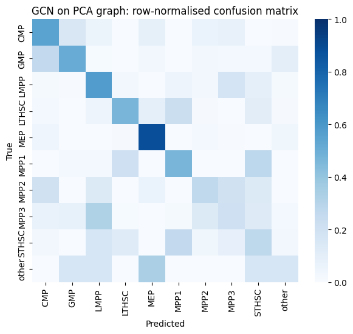

```python
gcn_confusion = confusion_matrix(y_labeled, gcn_oof, labels=class_codes, normalize="true")
fig, ax = plt.subplots(figsize=(6.2, 5.6))
sns.heatmap(
    gcn_confusion, cmap="Blues", vmin=0, vmax=1,
    xticklabels=[short_label_by_code[x] for x in class_codes],
    yticklabels=[short_label_by_code[x] for x in class_codes],
    ax=ax,
)
ax.set_title("GCN on PCA graph: row-normalised confusion matrix")
ax.set_xlabel("Predicted")
ax.set_ylabel("True")
plt.tight_layout()
plt.show()
```

| cell_type | GCN recall | GCN F1 | SVM on PCA-32 recall | SVM on PCA-32 F1 |
| --- | --- | --- | --- | --- |
| CMP | 0.55 | 0.62 | 0.56 | 0.63 |
| GMP | 0.51 | 0.50 | 0.62 | 0.58 |
| LMPP | 0.58 | 0.59 | 0.67 | 0.63 |
| LTHSC | 0.47 | 0.51 | 0.35 | 0.44 |
| MEP | 0.88 | 0.88 | 0.88 | 0.87 |
| MPP1 | 0.47 | 0.36 | 0.51 | 0.32 |
| MPP2 | 0.27 | 0.12 | 0.07 | 0.06 |
| MPP3 | 0.21 | 0.24 | 0.30 | 0.33 |
| STHSC | 0.27 | 0.27 | 0.44 | 0.44 |
| other | 0.17 | 0.06 | 0.00 | 0.00 |

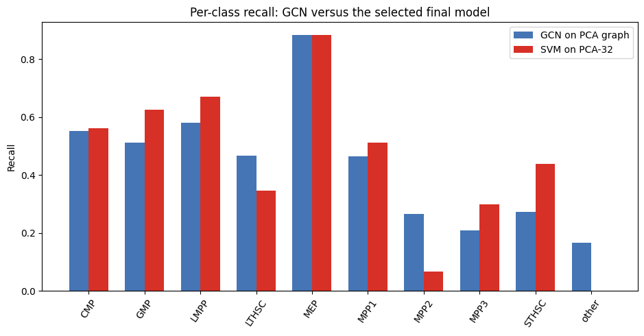

```python
gcn_precision, gcn_recall, gcn_f1, gcn_support = precision_recall_fscore_support(
    y_labeled, gcn_oof, labels=class_codes, zero_division=0
)
gcn_per_class = pd.DataFrame({
    "cell_type": [short_label_by_code[c] for c in class_codes],
    "GCN recall": gcn_recall,
    "GCN F1": gcn_f1,
}).set_index("cell_type")

final_model_per_class = per_class_metrics.loc[
    per_class_metrics["model"].eq(FINAL_MODEL_NAME)
].set_index("cell_type")[["recall", "F1"]].rename(
    columns={"recall": f"{FINAL_MODEL_NAME} recall", "F1": f"{FINAL_MODEL_NAME} F1"}
)
per_class_comparison = gcn_per_class.join(final_model_per_class).reindex(
    [short_label_by_code[c] for c in class_codes]
)
display(per_class_comparison.style.format("{:.2f}"))

fig, ax = plt.subplots(figsize=(9.5, 5))
x = np.arange(len(per_class_comparison))
width = 0.35
ax.bar(x - width / 2, per_class_comparison["GCN recall"], width, label="GCN on PCA graph", color="#4575b4")
ax.bar(x + width / 2, per_class_comparison[f"{FINAL_MODEL_NAME} recall"], width, label=FINAL_MODEL_NAME, color="#d73027")
ax.set_xticks(x)
ax.set_xticklabels(per_class_comparison.index, rotation=55)
ax.set_ylabel("Recall")
ax.set_title("Per-class recall: GCN versus the selected final model")
ax.legend()
plt.tight_layout()
plt.show()
```

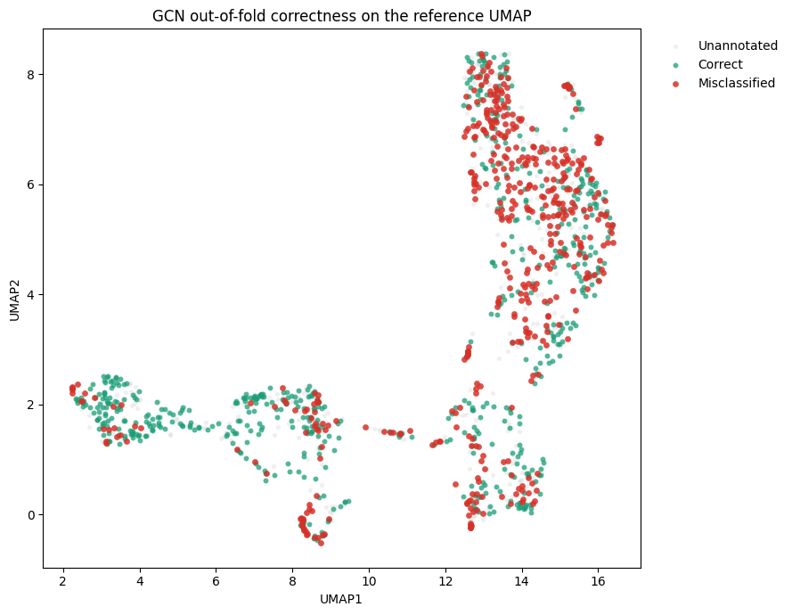

```python
correct_mask_full = np.zeros(adata_analysis.n_obs, dtype=bool)
correct_mask_full[annotated_indices] = (gcn_oof == y_labeled)

fig, ax = plt.subplots(figsize=(9, 7))
ax.scatter(
    X_umap[~annotated_mask, 0], X_umap[~annotated_mask, 1],
    color="#d9d9d9", s=14, alpha=0.4, linewidth=0, label="Unannotated",
)
ax.scatter(
    X_umap[annotated_mask & correct_mask_full, 0], X_umap[annotated_mask & correct_mask_full, 1],
    color="#1b9e77", s=18, alpha=0.75, linewidth=0, label="Correct",
)
ax.scatter(
    X_umap[annotated_mask & ~correct_mask_full, 0], X_umap[annotated_mask & ~correct_mask_full, 1],
    color="#d73027", s=24, alpha=0.85, linewidth=0, label="Misclassified",
)
ax.set_title("GCN out-of-fold correctness on the reference UMAP")
ax.set_xlabel("UMAP1")
ax.set_ylabel("UMAP2")
ax.legend(bbox_to_anchor=(1.02, 1), loc="upper left", frameon=False)
plt.tight_layout()
plt.show()
```

The broad confusion pattern resembles that of the selected SVM. `MEP_broad` remains the easiest class, while most mistakes concentrate in the overlapping progenitor region. The GCN obtains higher recall than the SVM for `MPP2_broad`, `other`, and `LTHSC_broad`, but the first two comparisons are based on only 15 and 6 cells in total. With three folds, each validation fold contains five `MPP2_broad` cells and two `other` cells, so a difference of one correctly classified cell changes recall substantially.

These rare-class gains are therefore compatible with the idea that message passing lets a sparsely represented class borrow information from neighbouring cells, but they do not demonstrate that mechanism or establish a stable advantage. The GCN loses recall on several better-represented classes and remains below the SVM on the main aggregate metrics. A larger labelled cohort or repeated nested cross-validation would be needed to decide whether the rare-class pattern is reproducible.

# 17. Refit on All Annotated Cells and Prediction of Unannotated Profiles

Model comparison is now complete. The predefined ranking in section 15 selected an RBF-kernel SVM on a 32-component PCA representation, while section 16 showed that the exploratory GCN remained slightly below it in macro-F1 and was evaluated under a different, transductive protocol. The SVM therefore remains the final predictive procedure.

The complete pipeline is fitted again from the beginning using all **1,074 annotated cells**:

1. a `StandardScaler` learns the mean and standard deviation of each of the 1,000 selected genes from the annotated subset;
2. PCA learns 32 components from those scaled annotated profiles;
3. an RBF SVM with $C=1$, `gamma="scale"`, and balanced class weights learns the ten-class boundary;
4. the fitted transformations and classifier are applied, without further fitting, to the **425 unannotated cells**.

The labels of these 425 cells are unknown, so this step cannot provide accuracy or F1 scores. The cells are also not an entirely external test cohort: their label-free profiles contributed earlier to global choices such as the HVG panel and the exploratory graph. They are therefore described as **unannotated target profiles**, not as an independent test set. The resulting labels are model-supported hypotheses, and probability summaries express model uncertainty rather than biological validation. No external prediction file is created or exported; the results remain part of the documented analysis.

```python
assert FINAL_MODEL_NAME == f"SVM on PCA-{LATENT_DIM}"

X_unannotated = X_hvg_unscaled[~annotated_mask]
unannotated_ids = adata_analysis.obs.loc[~annotated_mask, "ID"].astype(str).to_numpy()

final_pipeline = Pipeline([
    ("scale", StandardScaler()),
    ("pca", PCA(n_components=LATENT_DIM, svd_solver="full")),
    ("model", SVC(
        kernel="rbf",
        C=1.0,
        gamma="scale",
        class_weight="balanced",
        probability=True,
        random_state=SEED,
    )),
])
final_pipeline.fit(X_labeled, y_labeled)

unannotated_pred = final_pipeline.predict(X_unannotated).astype(int)
unannotated_prob = final_pipeline.predict_proba(X_unannotated)
probability_classes = final_pipeline.named_steps["model"].classes_.astype(int)
class_position = {code: position for position, code in enumerate(probability_classes)}
assigned_probability = np.array([
    unannotated_prob[row, class_position[code]]
    for row, code in enumerate(unannotated_pred)
])
normalised_entropy = np.apply_along_axis(
    lambda p: scipy_entropy(p, base=2) / np.log2(len(probability_classes)),
    axis=1,
    arr=unannotated_prob,
)

unannotated_results = pd.DataFrame({
    "ID": unannotated_ids,
    "predicted_code": unannotated_pred,
    "predicted_cell_type": [code_to_label[code] for code in unannotated_pred],
    "assigned_class_probability": assigned_probability,
    "normalised_probability_entropy": normalised_entropy,
})

annotated_distribution = (
    pd.Series(y_labeled).value_counts().reindex(class_codes, fill_value=0)
)
predicted_distribution = (
    pd.Series(unannotated_pred).value_counts().reindex(class_codes, fill_value=0)
)
distribution_comparison = pd.DataFrame({
    "cell_type": [code_to_label[code] for code in class_codes],
    "annotated_n": annotated_distribution.to_numpy(),
    "annotated_pct": 100 * annotated_distribution.to_numpy() / len(y_labeled),
    "predicted_n": predicted_distribution.to_numpy(),
    "predicted_pct": 100 * predicted_distribution.to_numpy() / len(unannotated_pred),
})

display(distribution_comparison.style.format({
    "annotated_pct": "{:.1f}%",
    "predicted_pct": "{:.1f}%",
}))

print("Unannotated profiles classified:", len(unannotated_results))
print(f"Median probability assigned to the predicted class: {np.median(assigned_probability):.3f}")
print(f"Predictions with assigned probability >= 0.60: {(assigned_probability >= 0.60).mean():.1%}")
print(f"Median normalised probability entropy: {np.median(normalised_entropy):.3f}")
```

|  | cell_type | annotated_n | annotated_pct | predicted_n | predicted_pct |
| --- | --- | --- | --- | --- | --- |
| 0 | CMP_broad | 232 | 21.6% | 75 | 17.6% |
| 1 | GMP_broad | 88 | 8.2% | 36 | 8.5% |
| 2 | LMPP_broad | 176 | 16.4% | 77 | 18.1% |
| 3 | LTHSC_broad | 75 | 7.0% | 21 | 4.9% |
| 4 | MEP_broad | 256 | 23.8% | 96 | 22.6% |
| 5 | MPP1_broad | 43 | 4.0% | 47 | 11.1% |
| 6 | MPP2_broad | 15 | 1.4% | 20 | 4.7% |
| 7 | MPP3_broad | 110 | 10.2% | 24 | 5.6% |
| 8 | STHSC_broad | 73 | 6.8% | 28 | 6.6% |
| 9 | other | 6 | 0.6% | 1 | 0.2% |

```
Unannotated profiles classified: 425
Median probability assigned to the predicted class: 0.596
Predictions with assigned probability >= 0.60: 49.6%
Median normalised probability entropy: 0.462
```

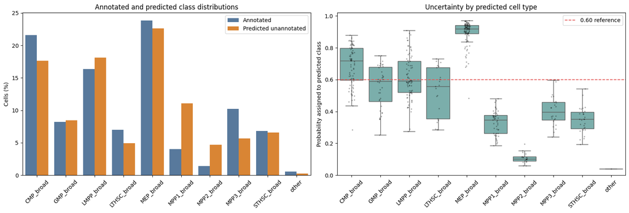

```python
plot_distribution = distribution_comparison.melt(
    id_vars="cell_type",
    value_vars=["annotated_pct", "predicted_pct"],
    var_name="subset",
    value_name="percentage",
)
plot_distribution["subset"] = plot_distribution["subset"].map({
    "annotated_pct": "Annotated",
    "predicted_pct": "Predicted unannotated",
})

fig, axes = plt.subplots(1, 2, figsize=(16, 5.5))
sns.barplot(
    data=plot_distribution,
    x="cell_type", y="percentage", hue="subset", ax=axes[0],
    palette=["#4c78a8", "#f58518"],
)
axes[0].set_title("Annotated and predicted class distributions")
axes[0].set_xlabel("")
axes[0].set_ylabel("Cells (%)")
axes[0].tick_params(axis="x", rotation=45)
axes[0].legend(title="")

sns.boxplot(
    data=unannotated_results,
    x="predicted_cell_type", y="assigned_class_probability",
    order=label_order, color="#72b7b2", showfliers=False, ax=axes[1],
)
sns.stripplot(
    data=unannotated_results,
    x="predicted_cell_type", y="assigned_class_probability",
    order=label_order, color="black", alpha=0.30, size=2.5, ax=axes[1],
)
axes[1].axhline(0.60, color="#e45756", linestyle="--", linewidth=1.3, label="0.60 reference")
axes[1].set_title("Uncertainty by predicted cell type")
axes[1].set_xlabel("")
axes[1].set_ylabel("Probability assigned to predicted class")
axes[1].set_ylim(0, 1.02)
axes[1].tick_params(axis="x", rotation=45)
axes[1].legend()

plt.tight_layout()
plt.show()
```

The selected SVM assigns a label to all 425 unannotated profiles. The largest predicted groups are `MEP_broad` (**96 cells; 22.6%**), `LMPP_broad` (**77; 18.1%**), and `CMP_broad` (**75; 17.6%**). `GMP_broad` and `STHSC_broad` remain close to their proportions in the annotated subset. The largest proportional changes concern `MPP1_broad` (**11.1% predicted versus 4.0% annotated**), `MPP2_broad` (**4.7% versus 1.4%**), and `MPP3_broad` (**5.6% versus 10.2%**). Only one profile is assigned to `other`.

These differences cannot be read directly as changes in biological abundance. Cross-validation showed that `MPP1_broad` can absorb cells from neighbouring stem/progenitor classes, that `MPP2_broad` has very low recall, and that `MPP3_broad` is frequently exchanged with `LMPP_broad` and the myeloid progenitor axis. The predicted distribution therefore combines the unknown composition of the unannotated subset with the known biases of the classifier. In particular, the near absence of `other` predictions reflects the difficulty of learning a six-cell residual class and does not show that comparable cells are biologically absent.

Uncertainty remains substantial. The median probability assigned to the predicted class is **0.596**, only **49.6%** of assignments reach 0.60, and the median normalised probability entropy is **0.462**. The boxplots show that confidence also varies across predicted populations. These values are consistent with the overlap observed throughout PCA, UMAP, clustering, and the cross-validated confusion matrices: many profiles lie near decision boundaries rather than inside sharply separated compartments. SVM probabilities are obtained through an additional calibration procedure and should be treated as model summaries, not as probabilities that a biological identity has been experimentally verified.

# 18. Integrated Discussion and Conclusions

This project examined how much biological and predictive structure can be supported by a relatively small hematopoietic scRNA-seq dataset whose preprocessing history is only partially documented. Rather than applying a conventional pipeline automatically, the analysis began by inspecting the numerical properties of the supplied expression matrix and then used those observations to justify each subsequent transformation.

**The numerical audit changed the preprocessing strategy.** Reversing candidate logarithmic transformations produced an exact integer-lattice match under base 2, strong evidence that the supplied values had already undergone a base-2 logarithmic transformation of scaled count-like data. The reconstructed per-cell sums were not constant, however, and their median of 416,732 cannot be interpreted as a known normalisation target. The exact upstream normalisation therefore remains unidentified. Preserving the supplied expression scale, rather than normalising and logging it a second time, is the most defensible choice supported by the available evidence.

Feature selection retained **1,000 highly variable genes**, the smallest candidate panel capturing at least 95% of the positive normalised-dispersion signal. PCA retained 50 working components because no smaller candidate reached the predefined neighbourhood-overlap threshold relative to the 50-component reference. This is a conservative representation decision, not evidence of biological continuity by itself: the criterion shows that smaller representations alter local neighbours, but its 50-component reference cannot independently prove the form of the underlying biology.

**The clearest unsupervised result is the distinctness of `MEP_broad`.** PCA and UMAP isolate a strong erythroid region, while K-means, Leiden, Ward clustering, and the Self-Organizing Map recover a compatible coarse separation. Differential expression associates that region with an erythroid programme including `Car2`, `Rhag`, and `Fth1`. These methods are structurally different but not statistically independent, because they reuse the same cells, preprocessing, and often the same PCA or distance geometry. Their agreement therefore supports a robust within-dataset pattern without replacing validation in an independent biological cohort.

The other populations overlap much more strongly. Stem and early progenitor annotations occupy neighbouring regions, while `CMP_broad`, `GMP_broad`, and `MPP3_broad` share part of a myeloid axis. This pattern is compatible with hematopoiesis as a continuous and branching differentiation process in which labels describe recognisable regions rather than perfectly separated compartments. It is not unique proof of that interpretation: broad annotation boundaries, technical variation, dropout, and small class sizes could generate similar overlap.

**More complex representation learning did not provide a clear advantage.** At the same 32-dimensional bottleneck, PCA reconstructed held-out cells slightly better than both the autoencoder and denoising autoencoder. The selected neural architecture lies at the boundary of the tested grid, and the same validation information contributed to early stopping and architecture comparison, making its selected reconstruction error mildly optimistic. The latent-variance analysis shows that no latent unit collapsed, but the decreasing plots cannot demonstrate a PCA-like intrinsic ordering because the variances were explicitly sorted. Marker correlations nevertheless indicate that the networks retained several interpretable erythroid, stem, and myeloid programmes.

Supervised evaluation used three stratified outer folds, a pragmatic compromise imposed by the six-cell `other` class. Fold-specific scalers, PCA transformations, autoencoders, and classifiers were fitted without access to their outer validation cells. The HVG panel, working PCA dimension, and exploratory autoencoder architecture were chosen globally without labels, so they remain transductive design choices. Moreover, the best result was selected from seventeen model/representation combinations evaluated on the same out-of-fold predictions. The resulting scores are therefore careful internal estimates, but they are not equivalent to external validation and may retain some model-selection optimism.

**The strongest inductive pipeline was an RBF SVM on PCA-32**, with out-of-fold accuracy **0.599**, macro-F1 **0.430**, and balanced accuracy **0.440**. The SVM on PCA-50 reached a slightly lower macro-F1 of 0.420 but a smaller fold-to-fold standard deviation, 0.004 rather than 0.019. The predefined ranking selects PCA-32 because macro-F1 has priority; a reader who values split-to-split stability more strongly could reasonably prefer the 50-component alternative.

The MLP remained weaker across the tested representations. Limited sample size, severe imbalance, and stochastic optimisation are plausible explanations, but the notebook did not isolate their causal contributions through dedicated ablation studies. The result supports the narrower conclusion that the tested MLP configuration did not improve classification under this protocol, not that neural networks are intrinsically unsuitable for scRNA-seq data.

**The exploratory GCN produced a competitive but not superior result.** It reached macro-F1 **0.414**, accuracy **0.562**, and balanced accuracy **0.437**, below the selected SVM on every aggregate metric. Its apparent gains for `MPP2_broad`, `other`, and `LTHSC_broad` are interesting, but the first two involve only 15 and 6 cells. In addition, the GCN evaluation is transductive: validation-node features and graph connections participate in message passing even though validation labels are masked. Its scores are therefore not directly equivalent to the inductive SVM evaluation. The experiment shows that graph structure can be used efficiently and may help some rare populations, but the current evidence is insufficient to claim a reproducible advantage.

After model selection, the PCA-32 SVM was refitted on all **1,074 annotated cells** and applied to the **425 unannotated profiles**. The largest predicted groups were `MEP_broad` (96 cells), `LMPP_broad` (77), and `CMP_broad` (75). The predicted subset contained proportionally more `MPP1_broad` and `MPP2_broad` and fewer `MPP3_broad` cells than the annotated subset, while only one cell was labelled `other`. These differences cannot be interpreted as population-frequency estimates because they combine the unknown biology of the unannotated subset with the model's class-specific error tendencies.

The uncertainty summaries reinforce this caution. The median probability assigned to the selected class was **0.596**, only **49.6%** of predictions reached 0.60, and the median normalised entropy was **0.462**. Thus, approximately half of the assignments do not receive even moderate probability support from the calibrated SVM. This is consistent with the blurred boundaries observed throughout the analysis. The predicted labels are consequently best understood as model-supported hypotheses, not experimentally verified identities.

Taken together, the project provides strong support for a distinct erythroid `MEP_broad` programme and for extensive transcriptional overlap among the remaining progenitor populations. Fine ten-class annotation remains difficult because the biological system is continuous, the reference labels are broad, and several classes are severely underrepresented. The most useful next steps would be an independent annotated cohort, greater sampling of rare populations, repeated validation, and trajectory-oriented methods designed to model gradual developmental change directly. Within the present data and methodological scope, the central conclusion is deliberately measured: the coarse biological structure is reproducible, whereas many individual fine-grained predictions remain uncertain.

# References

- Tang et al. (2009), [mRNA-Seq whole-transcriptome analysis of a single cell](https://doi.org/10.1038/nmeth.1315).
- Luecken & Theis (2019), [Current best practices in single-cell RNA-seq analysis](https://doi.org/10.15252/msb.20188746).
- Pietras et al. (2015), [Functionally distinct subsets of lineage-biased multipotent progenitors](https://doi.org/10.1016/j.stem.2015.05.003).
- Tusi et al. (2018), [Population snapshots predict early haematopoietic and erythroid hierarchies](https://pmc.ncbi.nlm.nih.gov/articles/PMC5969381/).
- Jolliffe & Cadima (2016), [Principal component analysis: a review and recent developments](https://doi.org/10.1098/rsta.2015.0202).
- van der Maaten & Hinton (2008), [Visualizing Data using t-SNE](https://www.jmlr.org/papers/v9/vandermaaten08a.html).
- McInnes, Healy & Melville (2018), [UMAP: Uniform Manifold Approximation and Projection](https://arxiv.org/abs/1802.03426).
- Wattenberg, Viégas & Johnson (2016), [How to Use t-SNE Effectively](https://distill.pub/2016/misread-tsne/).
- Traag, Waltman & van Eck (2019), [From Louvain to Leiden: guaranteeing well-connected communities](https://doi.org/10.1038/s41598-019-41695-z).
- Kohonen (1990), [The Self-Organizing Map](https://doi.org/10.1109/5.58325).
- Vincent et al. (2008), [Extracting and Composing Robust Features with Denoising Autoencoders](https://doi.org/10.1145/1390156.1390294).
- Kipf & Welling (2017), [Semi-Supervised Classification with Graph Convolutional Networks](https://arxiv.org/abs/1609.02907).
- Grinsztajn, Oyallon & Varoquaux (2022), [Why do tree-based models still outperform deep learning on tabular data?](https://arxiv.org/abs/2207.08815).